# Transformer — construindo um LLM do zero

O objetivo deste notebook é desenvolver, desde o início e passo a passo, um **transformer**: a arquitetura por trás dos modelos de linguagem do tipo GPT. Partimos de texto puro e chegamos a um modelo que gera texto, classifica mensagens e segue instruções.

| Capítulo | O que se constrói |
| --- | --- |
| 2 | Tokenização do texto, embeddings e o carregador de dados |
| 3 | O mecanismo de **atenção**: self-attention, máscara causal e multi-head |
| 4 | A arquitetura **GPT** completa: LayerNorm, GELU, bloco transformer e o modelo |
| 5 | **Pré-treinamento**, avaliação e carregamento dos pesos oficiais do GPT-2 |
| 6 | **Fine-tuning** para classificar mensagens como spam |
| 7 | **Fine-tuning com instruções**, transformando o modelo em um assistente |

Antes de cada célula de código há uma nota em português (🇧🇷) dizendo, em poucas palavras, o que ela faz.

## Como executar este notebook no Google Colab, com o Google Drive

O notebook foi preparado para rodar no **Google Colab**, guardando no **Google Drive** o próprio notebook, os dados baixados e os modelos treinados. Assim nada se perde quando a sessão do Colab termina.

### 1. O que é preciso

- Uma conta Google, com acesso ao [Google Drive](https://drive.google.com) e ao [Google Colab](https://colab.research.google.com).
- Cerca de **8 GB livres no Google Drive** (a conta gratuita tem 15 GB). As tabelas do passo 6 mostram o que ocupa esse espaço.

### 2. Salvar o notebook no Google Drive

1. Abra o [Google Drive](https://drive.google.com).
2. Em **Meu Drive**, crie uma pasta chamada **`Transformer`**: botão **+ Novo → Nova pasta**.
3. Entre na pasta e envie o arquivo **`Transformer.ipynb`**: botão **+ Novo → Upload de arquivo**.

### 3. Abrir o notebook no Colab

1. No Drive, clique com o botão direito em `Transformer.ipynb` → **Abrir com → Google Colaboratory**.
2. Se o Colab não aparecer na lista: **Abrir com → Conectar mais apps**, procure **Colaboratory**, instale e repita o passo anterior.
3. Outra forma: em colab.research.google.com, menu **Arquivo → Abrir notebook → Google Drive** e escolha `Meu Drive/Transformer/Transformer.ipynb`.

As alterações feitas no Colab são salvas automaticamente no mesmo arquivo do Drive.

### 4. Ativar a GPU

Menu **Ambiente de execução → Alterar o tipo de ambiente de execução → Acelerador de hardware: GPU T4 → Salvar**. Sem GPU o notebook funciona, mas os treinos dos capítulos 5, 6 e 7 ficam muito lentos.

### 5. Conectar o Google Drive

Execute a célula **Conectar o Google Drive**, logo abaixo. O Colab pede autorização para acessar o seu Drive: aceite. A partir daí, a pasta de trabalho passa a ser `Meu Drive/Transformer`, e tudo o que o notebook baixar ou gravar fica nela. A célula também informa se a GPU está ativa.

### 6. Preparar o ambiente e baixar os arquivos

1. Execute as células da seção **Preparação do ambiente**: elas instalam o `tiktoken` e gravam na pasta `suporte/` os módulos com o código que cada capítulo reaproveita dos anteriores.
2. Opcional: execute a célula **Baixar todos os arquivos de uma vez**. Se preferir pular, não há problema: cada capítulo baixa sozinho o que precisa, na primeira vez em que é executado.

Arquivos baixados da internet (ficam na pasta `Transformer` do Drive):

| Arquivo ou pasta | Usado no | Origem | Tamanho |
| --- | --- | --- | --- |
| `the-verdict.txt` | cap. 2 e 5 | https://raw.githubusercontent.com/rasbt/LLMs-from-scratch/main/ch02/01_main-chapter-code/the-verdict.txt | 20 KB |
| `gpt2/124M/` (7 arquivos) | cap. 5 e 6 | [https://openaipublic.blob.core.windows.net/gpt-2/models/124M/](https://openaipublic.blob.core.windows.net/gpt-2/models/124M/checkpoint) | 477 MB |
| `sms_spam_collection/` | cap. 6 | https://archive.ics.uci.edu/static/public/228/sms+spam+collection.zip | 200 KB |
| `instruction-data.json` | cap. 7 | https://raw.githubusercontent.com/rasbt/LLMs-from-scratch/main/ch07/01_main-chapter-code/instruction-data.json | 200 KB |
| `gpt2/355M/` (7 arquivos) | cap. 7 | [https://openaipublic.blob.core.windows.net/gpt-2/models/355M/](https://openaipublic.blob.core.windows.net/gpt-2/models/355M/checkpoint) | 1,4 GB |

Os 7 arquivos de cada pasta `gpt2/…` são: `checkpoint`, `encoder.json`, `hparams.json`, `model.ckpt.data-00000-of-00001`, `model.ckpt.index`, `model.ckpt.meta` e `vocab.bpe`.

Arquivos gravados pelo próprio notebook durante a execução:

| Arquivo | Capítulo | Tamanho aproximado |
| --- | --- | --- |
| `model.pth` e `model_and_optimizer.pth` | 5 | 650 MB e 1,9 GB |
| `train.csv`, `validation.csv`, `test.csv` e `review_classifier.pth` | 6 | 160 KB e 550 MB |
| `gpt2-medium355M-sft.pth` e `instruction-data-with-response.json` | 7 | 1,7 GB e 30 KB |
| gráficos `.pdf` (`loss-plot.pdf`, `accuracy-plot.pdf` etc.) | 5, 6 e 7 | poucos KB |

### 7. Executar

Execute os capítulos **em ordem**, célula por célula (**Shift + Enter**), ou use **Ambiente de execução → Executar tudo**.

### Dicas

- **Se a sessão cair** (o Colab gratuito desconecta depois de um tempo sem uso ou de algumas horas): os arquivos continuam no Drive. Reabra o notebook, execute de novo **Conectar o Google Drive** e a **Preparação do ambiente** e recomece do **início do capítulo** em que parou. Cada capítulo pode ser executado sem os anteriores, porque importa da pasta `suporte/` o que precisa.
- **Sem Google Drive:** pule a célula do Drive. Os arquivos ficam em `/content`, que é apagado quando a sessão termina.
- **Seção 7.8 (avaliação com o Llama 3):** precisa do [Ollama](https://ollama.com) instalado e rodando no computador local. No Colab essas células não funcionam; pule-as.
- **Saídas que já aparecem nas células:** vêm de uma execução completa feita numa GPU NVIDIA RTX 3060. Ao executar de novo, os números podem variar um pouco.
- **No computador local (Jupyter):** pule a célula do Drive; os arquivos ficam na pasta do notebook. É preciso ter Python com `torch`, `tiktoken`, `tensorflow`, `matplotlib`, `pandas`, `numpy`, `tqdm`, `requests` e `psutil`.

> 🇧🇷 **O que esta célula faz:** Conecta o Google Drive e passa a usar a pasta `Meu Drive/Transformer` como pasta de trabalho; fora do Colab, usa a pasta atual. Também informa se há GPU disponível.

```python
#@title Conectar o Google Drive
import os
import torch

PASTA_NO_DRIVE = "/content/drive/MyDrive/Transformer"

try:
    from google.colab import drive
    drive.mount("/content/drive")
    os.makedirs(PASTA_NO_DRIVE, exist_ok=True)
    os.chdir(PASTA_NO_DRIVE)
except ImportError:
    print("Fora do Google Colab: os arquivos ficam na pasta atual.")

print("Pasta de trabalho:", os.getcwd())
print("GPU:", torch.cuda.get_device_name(0) if torch.cuda.is_available()
      else "nenhuma (no Colab: Ambiente de execução → Alterar o tipo de ambiente de execução → GPU T4)")
```

## Preparação do ambiente

As células abaixo deixam o notebook pronto para rodar em qualquer lugar, inclusive no Google Colab:

- instalam a biblioteca `tiktoken` (o tokenizador usado pelo GPT-2);
- baixam o conto *The Verdict*, o texto usado para treinar o modelo;
- gravam na pasta `suporte/` os módulos auxiliares. Cada capítulo importa dali o código construído nos capítulos anteriores.

No Colab, as células de gravação dos módulos aparecem recolhidas; basta executá-las.

> 🇧🇷 **O que esta célula faz:** Instala o tokenizador `tiktoken` e confere as versões das bibliotecas principais.

```python
%pip install -q tiktoken

from importlib.metadata import version
for pacote in ["torch", "tiktoken", "tensorflow", "matplotlib", "pandas", "numpy"]:
    try:
        print(f"{pacote}: {version(pacote)}")
    except Exception:
        print(f"{pacote}: NÃO INSTALADO")
```

> 🇧🇷 **O que esta célula faz:** Baixa o conto *The Verdict*, que será o texto de treino, caso ele ainda não esteja na pasta.

```python
import os
import urllib.request

if not os.path.exists("the-verdict.txt"):
    url = "https://raw.githubusercontent.com/rasbt/LLMs-from-scratch/main/ch02/01_main-chapter-code/the-verdict.txt"
    urllib.request.urlretrieve(url, "the-verdict.txt")
print("the-verdict.txt:", os.path.getsize("the-verdict.txt"), "bytes")
```

> 🇧🇷 **O que esta célula faz:** Grava o módulo auxiliar `suporte/previous_chapters_cap04.py`: código do capítulo 3 usado no capítulo 4.

```python
#@title Código do capítulo 3 usado no capítulo 4 → suporte/previous_chapters_cap04.py
import os
os.makedirs("suporte", exist_ok=True)
open("suporte/__init__.py", "a").close()

codigo = r'''# Copyright (c) Sebastian Raschka under Apache License 2.0 (see LICENSE.txt).
# Source for "Build a Large Language Model From Scratch"
#   - https://www.manning.com/books/build-a-large-language-model-from-scratch
# Code: https://github.com/rasbt/LLMs-from-scratch

import tiktoken
import torch
import torch.nn as nn
from torch.utils.data import Dataset, DataLoader


class GPTDatasetV1(Dataset):
    def __init__(self, txt, tokenizer, max_length, stride):
        self.input_ids = []
        self.target_ids = []

        # Tokenize the entire text
        token_ids = self.tokenizer.encode(txt)

        # Use a sliding window to chunk the book into overlapping sequences of max_length
        for i in range(0, len(token_ids) - max_length, stride):
            input_chunk = token_ids[i:i + max_length]
            target_chunk = token_ids[i + 1: i + max_length + 1]
            self.input_ids.append(torch.tensor(input_chunk))
            self.target_ids.append(torch.tensor(target_chunk))

    def __len__(self):
        return len(self.input_ids)

    def __getitem__(self, idx):
        return self.input_ids[idx], self.target_ids[idx]


def create_dataloader_v1(txt, batch_size=4, max_length=256,
                         stride=128, shuffle=True, drop_last=True, num_workers=0):
    # Initialize the tokenizer
    tokenizer = tiktoken.get_encoding("gpt2")

    # Create dataset
    dataset = GPTDatasetV1(txt, tokenizer, max_length, stride)

    # Create dataloader
    dataloader = DataLoader(
        dataset, batch_size=batch_size, shuffle=shuffle, drop_last=drop_last, num_workers=0)

    return dataloader


class MultiHeadAttention(nn.Module):
    def __init__(self, d_in, d_out, context_length, dropout, num_heads, qkv_bias=False):
        super().__init__()
        assert d_out % num_heads == 0, "d_out must be divisible by num_heads"

        self.d_out = d_out
        self.num_heads = num_heads
        self.head_dim = d_out // num_heads  # Reduce the projection dim to match desired output dim

        self.W_query = nn.Linear(d_in, d_out, bias=qkv_bias)
        self.W_key = nn.Linear(d_in, d_out, bias=qkv_bias)
        self.W_value = nn.Linear(d_in, d_out, bias=qkv_bias)
        self.out_proj = nn.Linear(d_out, d_out)  # Linear layer to combine head outputs
        self.dropout = nn.Dropout(dropout)
        self.register_buffer('mask', torch.triu(torch.ones(context_length, context_length), diagonal=1))

    def forward(self, x):
        b, num_tokens, d_in = x.shape

        keys = self.W_key(x)  # Shape: (b, num_tokens, d_out)
        queries = self.W_query(x)
        values = self.W_value(x)

        # We implicitly split the matrix by adding a `num_heads` dimension
        # Unroll last dim: (b, num_tokens, d_out) -> (b, num_tokens, num_heads, head_dim)
        keys = keys.view(b, num_tokens, self.num_heads, self.head_dim)
        values = values.view(b, num_tokens, self.num_heads, self.head_dim)
        queries = queries.view(b, num_tokens, self.num_heads, self.head_dim)

        # Transpose: (b, num_tokens, num_heads, head_dim) -> (b, num_heads, num_tokens, head_dim)
        keys = keys.transpose(1, 2)
        queries = queries.transpose(1, 2)
        values = values.transpose(1, 2)

        # Compute scaled dot-product attention (aka self-attention) with a causal mask
        attn_scores = queries @ keys.transpose(2, 3)  # Dot product for each head

        # Original mask truncated to the number of tokens and converted to boolean
        mask_bool = self.mask.bool()[:num_tokens, :num_tokens]

        # Use the mask to fill attention scores
        attn_scores.masked_fill_(mask_bool, -torch.inf)

        attn_weights = torch.softmax(attn_scores / keys.shape[-1]**0.5, dim=-1)
        attn_weights = self.dropout(attn_weights)

        # Shape: (b, num_tokens, num_heads, head_dim)
        context_vec = (attn_weights @ values).transpose(1, 2)

        # Combine heads, where self.d_out = self.num_heads * self.head_dim
        context_vec = context_vec.contiguous().view(b, num_tokens, self.d_out)
        context_vec = self.out_proj(context_vec)  # optional projection

        return context_vec
'''

with open("suporte/previous_chapters_cap04.py", "w", encoding="utf-8") as f:
    f.write(codigo)
print("Gravado: suporte/previous_chapters_cap04.py")
```

> 🇧🇷 **O que esta célula faz:** Grava o módulo auxiliar `suporte/previous_chapters_cap05.py`: código dos capítulos 2 a 4 usado no capítulo 5.

```python
#@title Código dos capítulos 2 a 4 usado no capítulo 5 → suporte/previous_chapters_cap05.py
import os
os.makedirs("suporte", exist_ok=True)
open("suporte/__init__.py", "a").close()

codigo = r'''# Copyright (c) Sebastian Raschka under Apache License 2.0 (see LICENSE.txt).
# Source for "Build a Large Language Model From Scratch"
#   - https://www.manning.com/books/build-a-large-language-model-from-scratch
# Code: https://github.com/rasbt/LLMs-from-scratch
#
# This file collects all the relevant code that we covered thus far
# throughout Chapters 2-4.
# This file can be run as a standalone script.

import tiktoken
import torch
import torch.nn as nn
from torch.utils.data import Dataset, DataLoader

#####################################
# Chapter 2
#####################################


class GPTDatasetV1(Dataset):
    def __init__(self, txt, tokenizer, max_length, stride):
        self.input_ids = []
        self.target_ids = []

        # Tokenize the entire text
        token_ids = tokenizer.encode(txt)

        # Use a sliding window to chunk the book into overlapping sequences of max_length
        for i in range(0, len(token_ids) - max_length, stride):
            input_chunk = token_ids[i:i + max_length]
            target_chunk = token_ids[i + 1: i + max_length + 1]
            self.input_ids.append(torch.tensor(input_chunk))
            self.target_ids.append(torch.tensor(target_chunk))

    def __len__(self):
        return len(self.input_ids)

    def __getitem__(self, idx):
        return self.input_ids[idx], self.target_ids[idx]


def create_dataloader_v1(txt, batch_size=4, max_length=256,
                         stride=128, shuffle=True, drop_last=True, num_workers=0):
    # Initialize the tokenizer
    tokenizer = tiktoken.get_encoding("gpt2")

    # Create dataset
    dataset = GPTDatasetV1(txt, tokenizer, max_length, stride)

    # Create dataloader
    dataloader = DataLoader(
        dataset, batch_size=batch_size, shuffle=shuffle, drop_last=drop_last, num_workers=0)

    return dataloader


#####################################
# Chapter 3
#####################################
class MultiHeadAttention(nn.Module):
    def __init__(self, d_in, d_out, context_length, dropout, num_heads, qkv_bias=False):
        super().__init__()
        assert d_out % num_heads == 0, "d_out must be divisible by n_heads"

        self.d_out = d_out
        self.num_heads = num_heads
        self.head_dim = d_out // num_heads  # Reduce the projection dim to match desired output dim

        self.W_query = nn.Linear(d_in, d_out, bias=qkv_bias)
        self.W_key = nn.Linear(d_in, d_out, bias=qkv_bias)
        self.W_value = nn.Linear(d_in, d_out, bias=qkv_bias)
        self.out_proj = nn.Linear(d_out, d_out)  # Linear layer to combine head outputs
        self.dropout = nn.Dropout(dropout)
        self.register_buffer('mask', torch.triu(torch.ones(context_length, context_length), diagonal=1))

    def forward(self, x):
        b, num_tokens, d_in = x.shape

        keys = self.W_key(x)  # Shape: (b, num_tokens, d_out)
        queries = self.W_query(x)
        values = self.W_value(x)

        # We implicitly split the matrix by adding a `num_heads` dimension
        # Unroll last dim: (b, num_tokens, d_out) -> (b, num_tokens, num_heads, head_dim)
        keys = keys.view(b, num_tokens, self.num_heads, self.head_dim)
        values = values.view(b, num_tokens, self.num_heads, self.head_dim)
        queries = queries.view(b, num_tokens, self.num_heads, self.head_dim)

        # Transpose: (b, num_tokens, num_heads, head_dim) -> (b, num_heads, num_tokens, head_dim)
        keys = keys.transpose(1, 2)
        queries = queries.transpose(1, 2)
        values = values.transpose(1, 2)

        # Compute scaled dot-product attention (aka self-attention) with a causal mask
        attn_scores = queries @ keys.transpose(2, 3)  # Dot product for each head

        # Original mask truncated to the number of tokens and converted to boolean
        mask_bool = self.mask.bool()[:num_tokens, :num_tokens]

        # Use the mask to fill attention scores
        attn_scores.masked_fill_(mask_bool, -torch.inf)

        attn_weights = torch.softmax(attn_scores / keys.shape[-1]**0.5, dim=-1)
        attn_weights = self.dropout(attn_weights)

        # Shape: (b, num_tokens, num_heads, head_dim)
        context_vec = (attn_weights @ values).transpose(1, 2)

        # Combine heads, where self.d_out = self.num_heads * self.head_dim
        context_vec = context_vec.reshape(b, num_tokens, self.d_out)
        context_vec = self.out_proj(context_vec)  # optional projection

        return context_vec


#####################################
# Chapter 4
#####################################
class LayerNorm(nn.Module):
    def __init__(self, emb_dim):
        super().__init__()
        self.eps = 1e-5
        self.scale = nn.Parameter(torch.ones(emb_dim))
        self.shift = nn.Parameter(torch.zeros(emb_dim))

    def forward(self, x):
        mean = x.mean(dim=-1, keepdim=True)
        var = x.var(dim=-1, keepdim=True, unbiased=False)
        norm_x = (x - mean) / torch.sqrt(var + self.eps)
        return self.scale * norm_x + self.shift


class GELU(nn.Module):
    def __init__(self):
        super().__init__()

    def forward(self, x):
        return 0.5 * x * (1 + torch.tanh(
            torch.sqrt(torch.tensor(2.0 / torch.pi)) *
            (x + 0.044715 * torch.pow(x, 3))
        ))


class FeedForward(nn.Module):
    def __init__(self, cfg):
        super().__init__()
        self.layers = nn.Sequential(
            nn.Linear(cfg["emb_dim"], 4 * cfg["emb_dim"]),
            GELU(),
            nn.Linear(4 * cfg["emb_dim"], cfg["emb_dim"]),
        )

    def forward(self, x):
        return self.layers(x)


class TransformerBlock(nn.Module):
    def __init__(self, cfg):
        super().__init__()
        self.att = MultiHeadAttention(
            d_in=cfg["emb_dim"],
            d_out=cfg["emb_dim"],
            context_length=cfg["context_length"],
            num_heads=cfg["n_heads"],
            dropout=cfg["drop_rate"],
            qkv_bias=cfg["qkv_bias"])
        self.ff = FeedForward(cfg)
        self.norm1 = LayerNorm(cfg["emb_dim"])
        self.norm2 = LayerNorm(cfg["emb_dim"])
        self.drop_shortcut = nn.Dropout(cfg["drop_rate"])

    def forward(self, x):
        # Shortcut connection for attention block
        shortcut = x
        x = self.norm1(x)
        x = self.att(x)   # Shape [batch_size, num_tokens, emb_size]
        x = self.drop_shortcut(x)
        x = x + shortcut  # Add the original input back

        # Shortcut connection for feed-forward block
        shortcut = x
        x = self.norm2(x)
        x = self.ff(x)
        x = self.drop_shortcut(x)
        x = x + shortcut  # Add the original input back

        return x


class GPTModel(nn.Module):
    def __init__(self, cfg):
        super().__init__()
        self.tok_emb = nn.Embedding(cfg["vocab_size"], cfg["emb_dim"])
        self.pos_emb = nn.Embedding(cfg["context_length"], cfg["emb_dim"])
        self.drop_emb = nn.Dropout(cfg["drop_rate"])

        self.trf_blocks = nn.Sequential(
            *[TransformerBlock(cfg) for _ in range(cfg["n_layers"])])

        self.final_norm = LayerNorm(cfg["emb_dim"])
        self.out_head = nn.Linear(cfg["emb_dim"], cfg["vocab_size"], bias=False)

    def forward(self, in_idx):
        batch_size, seq_len = in_idx.shape
        tok_embeds = self.tok_emb(in_idx)
        pos_embeds = self.pos_emb(torch.arange(seq_len, device=in_idx.device))
        x = tok_embeds + pos_embeds  # Shape [batch_size, num_tokens, emb_size]
        x = self.drop_emb(x)
        x = self.trf_blocks(x)
        x = self.final_norm(x)
        logits = self.out_head(x)
        return logits


def generate_text_simple(model, idx, max_new_tokens, context_size):
    # idx is (B, T) array of indices in the current context
    for _ in range(max_new_tokens):

        # Crop current context if it exceeds the supported context size
        # E.g., if LLM supports only 5 tokens, and the context size is 10
        # then only the last 5 tokens are used as context
        idx_cond = idx[:, -context_size:]

        # Get the predictions
        with torch.no_grad():
            logits = model(idx_cond)

        # Focus only on the last time step
        # (batch, n_token, vocab_size) becomes (batch, vocab_size)
        logits = logits[:, -1, :]

        # Get the idx of the vocab entry with the highest logits value
        idx_next = torch.argmax(logits, dim=-1, keepdim=True)  # (batch, 1)

        # Append sampled index to the running sequence
        idx = torch.cat((idx, idx_next), dim=1)  # (batch, n_tokens+1)

    return idx


if __name__ == "__main__":

    GPT_CONFIG_124M = {
        "vocab_size": 50257,     # Vocabulary size
        "context_length": 1024,  # Context length
        "emb_dim": 768,          # Embedding dimension
        "n_heads": 12,           # Number of attention heads
        "n_layers": 12,          # Number of layers
        "drop_rate": 0.1,        # Dropout rate
        "qkv_bias": False        # Query-Key-Value bias
    }

    torch.manual_seed(123)
    model = GPTModel(GPT_CONFIG_124M)
    model.eval()  # disable dropout

    start_context = "Hello, I am"

    tokenizer = tiktoken.get_encoding("gpt2")
    encoded = tokenizer.encode(start_context)
    encoded_tensor = torch.tensor(encoded).unsqueeze(0)

    print(f"\n{50*'='}\n{22*' '}IN\n{50*'='}")
    print("\nInput text:", start_context)
    print("Encoded input text:", encoded)
    print("encoded_tensor.shape:", encoded_tensor.shape)

    out = generate_text_simple(
        model=model,
        idx=encoded_tensor,
        max_new_tokens=10,
        context_size=GPT_CONFIG_124M["context_length"]
    )
    decoded_text = tokenizer.decode(out.squeeze(0).tolist())

    print(f"\n\n{50*'='}\n{22*' '}OUT\n{50*'='}")
    print("\nOutput:", out)
    print("Output length:", len(out[0]))
    print("Output text:", decoded_text)
'''

with open("suporte/previous_chapters_cap05.py", "w", encoding="utf-8") as f:
    f.write(codigo)
print("Gravado: suporte/previous_chapters_cap05.py")
```

> 🇧🇷 **O que esta célula faz:** Grava o módulo auxiliar `suporte/previous_chapters_cap06.py`: código dos capítulos 2 a 5 usado no capítulo 6.

```python
#@title Código dos capítulos 2 a 5 usado no capítulo 6 → suporte/previous_chapters_cap06.py
import os
os.makedirs("suporte", exist_ok=True)
open("suporte/__init__.py", "a").close()

codigo = r'''# Copyright (c) Sebastian Raschka under Apache License 2.0 (see LICENSE.txt).
# Source for "Build a Large Language Model From Scratch"
#   - https://www.manning.com/books/build-a-large-language-model-from-scratch
# Code: https://github.com/rasbt/LLMs-from-scratch
#
# This file collects all the relevant code that we covered thus far
# throughout Chapters 2-5.
# This file can be run as a standalone script.

import numpy as np
import tiktoken
import torch
import torch.nn as nn
from torch.utils.data import Dataset, DataLoader

#####################################
# Chapter 2
#####################################


class GPTDatasetV1(Dataset):
    def __init__(self, txt, tokenizer, max_length, stride):
        self.input_ids = []
        self.target_ids = []

        # Tokenize the entire text
        token_ids = tokenizer.encode(txt, allowed_special={"<|endoftext|>"})

        # Use a sliding window to chunk the book into overlapping sequences of max_length
        for i in range(0, len(token_ids) - max_length, stride):
            input_chunk = token_ids[i:i + max_length]
            target_chunk = token_ids[i + 1: i + max_length + 1]
            self.input_ids.append(torch.tensor(input_chunk))
            self.target_ids.append(torch.tensor(target_chunk))

    def __len__(self):
        return len(self.input_ids)

    def __getitem__(self, idx):
        return self.input_ids[idx], self.target_ids[idx]


def create_dataloader_v1(txt, batch_size=4, max_length=256,
                         stride=128, shuffle=True, drop_last=True):
    # Initialize the tokenizer
    tokenizer = tiktoken.get_encoding("gpt2")

    # Create dataset
    dataset = GPTDatasetV1(txt, tokenizer, max_length, stride)

    # Create dataloader
    dataloader = DataLoader(
        dataset, batch_size=batch_size, shuffle=shuffle, drop_last=drop_last)

    return dataloader


#####################################
# Chapter 3
#####################################
class MultiHeadAttention(nn.Module):
    def __init__(self, d_in, d_out, context_length, dropout, num_heads, qkv_bias=False):
        super().__init__()
        assert d_out % num_heads == 0, "d_out must be divisible by n_heads"

        self.d_out = d_out
        self.num_heads = num_heads
        self.head_dim = d_out // num_heads  # Reduce the projection dim to match desired output dim

        self.W_query = nn.Linear(d_in, d_out, bias=qkv_bias)
        self.W_key = nn.Linear(d_in, d_out, bias=qkv_bias)
        self.W_value = nn.Linear(d_in, d_out, bias=qkv_bias)
        self.out_proj = nn.Linear(d_out, d_out)  # Linear layer to combine head outputs
        self.dropout = nn.Dropout(dropout)
        self.register_buffer('mask', torch.triu(torch.ones(context_length, context_length), diagonal=1))

    def forward(self, x):
        b, num_tokens, d_in = x.shape

        keys = self.W_key(x)  # Shape: (b, num_tokens, d_out)
        queries = self.W_query(x)
        values = self.W_value(x)

        # We implicitly split the matrix by adding a `num_heads` dimension
        # Unroll last dim: (b, num_tokens, d_out) -> (b, num_tokens, num_heads, head_dim)
        keys = keys.view(b, num_tokens, self.num_heads, self.head_dim)
        values = values.view(b, num_tokens, self.num_heads, self.head_dim)
        queries = queries.view(b, num_tokens, self.num_heads, self.head_dim)

        # Transpose: (b, num_tokens, num_heads, head_dim) -> (b, num_heads, num_tokens, head_dim)
        keys = keys.transpose(1, 2)
        queries = queries.transpose(1, 2)
        values = values.transpose(1, 2)

        # Compute scaled dot-product attention (aka self-attention) with a causal mask
        attn_scores = queries @ keys.transpose(2, 3)  # Dot product for each head

        # Original mask truncated to the number of tokens and converted to boolean
        mask_bool = self.mask.bool()[:num_tokens, :num_tokens]

        # Use the mask to fill attention scores
        attn_scores.masked_fill_(mask_bool, -torch.inf)

        attn_weights = torch.softmax(attn_scores / keys.shape[-1]**0.5, dim=-1)
        attn_weights = self.dropout(attn_weights)

        # Shape: (b, num_tokens, num_heads, head_dim)
        context_vec = (attn_weights @ values).transpose(1, 2)

        # Combine heads, where self.d_out = self.num_heads * self.head_dim
        context_vec = context_vec.reshape(b, num_tokens, self.d_out)
        context_vec = self.out_proj(context_vec)  # optional projection

        return context_vec


#####################################
# Chapter 4
#####################################
class LayerNorm(nn.Module):
    def __init__(self, emb_dim):
        super().__init__()
        self.eps = 1e-5
        self.scale = nn.Parameter(torch.ones(emb_dim))
        self.shift = nn.Parameter(torch.zeros(emb_dim))

    def forward(self, x):
        mean = x.mean(dim=-1, keepdim=True)
        var = x.var(dim=-1, keepdim=True, unbiased=False)
        norm_x = (x - mean) / torch.sqrt(var + self.eps)
        return self.scale * norm_x + self.shift


class GELU(nn.Module):
    def __init__(self):
        super().__init__()

    def forward(self, x):
        return 0.5 * x * (1 + torch.tanh(
            torch.sqrt(torch.tensor(2.0 / torch.pi)) *
            (x + 0.044715 * torch.pow(x, 3))
        ))


class FeedForward(nn.Module):
    def __init__(self, cfg):
        super().__init__()
        self.layers = nn.Sequential(
            nn.Linear(cfg["emb_dim"], 4 * cfg["emb_dim"]),
            GELU(),
            nn.Linear(4 * cfg["emb_dim"], cfg["emb_dim"]),
        )

    def forward(self, x):
        return self.layers(x)


class TransformerBlock(nn.Module):
    def __init__(self, cfg):
        super().__init__()
        self.att = MultiHeadAttention(
            d_in=cfg["emb_dim"],
            d_out=cfg["emb_dim"],
            context_length=cfg["context_length"],
            num_heads=cfg["n_heads"],
            dropout=cfg["drop_rate"],
            qkv_bias=cfg["qkv_bias"])
        self.ff = FeedForward(cfg)
        self.norm1 = LayerNorm(cfg["emb_dim"])
        self.norm2 = LayerNorm(cfg["emb_dim"])
        self.drop_resid = nn.Dropout(cfg["drop_rate"])
```

```python
    def forward(self, x):
        # Shortcut connection for attention block
        shortcut = x
        x = self.norm1(x)
        x = self.att(x)   # Shape [batch_size, num_tokens, emb_size]
        x = self.drop_resid(x)
        x = x + shortcut  # Add the original input back

        # Shortcut connection for feed-forward block
        shortcut = x
        x = self.norm2(x)
        x = self.ff(x)
        x = self.drop_resid(x)
        x = x + shortcut  # Add the original input back

        return x


class GPTModel(nn.Module):
    def __init__(self, cfg):
        super().__init__()
        self.tok_emb = nn.Embedding(cfg["vocab_size"], cfg["emb_dim"])
        self.pos_emb = nn.Embedding(cfg["context_length"], cfg["emb_dim"])
        self.drop_emb = nn.Dropout(cfg["drop_rate"])

        self.trf_blocks = nn.Sequential(
            *[TransformerBlock(cfg) for _ in range(cfg["n_layers"])])

        self.final_norm = LayerNorm(cfg["emb_dim"])
        self.out_head = nn.Linear(cfg["emb_dim"], cfg["vocab_size"], bias=False)

    def forward(self, in_idx):
        batch_size, seq_len = in_idx.shape
        tok_embeds = self.tok_emb(in_idx)
        pos_embeds = self.pos_emb(torch.arange(seq_len, device=in_idx.device))
        x = tok_embeds + pos_embeds  # Shape [batch_size, num_tokens, emb_size]
        x = self.drop_emb(x)
        x = self.trf_blocks(x)
        x = self.final_norm(x)
        logits = self.out_head(x)
        return logits


def generate_text_simple(model, idx, max_new_tokens, context_size):
    # idx is (B, T) array of indices in the current context
    for _ in range(max_new_tokens):

        # Crop current context if it exceeds the supported context size
        # E.g., if LLM supports only 5 tokens, and the context size is 10
        # then only the last 5 tokens are used as context
        idx_cond = idx[:, -context_size:]

        # Get the predictions
        with torch.no_grad():
            logits = model(idx_cond)

        # Focus only on the last time step
        # (batch, n_token, vocab_size) becomes (batch, vocab_size)
        logits = logits[:, -1, :]

        # Get the idx of the vocab entry with the highest logits value
        idx_next = torch.argmax(logits, dim=-1, keepdim=True)  # (batch, 1)

        # Append sampled index to the running sequence
        idx = torch.cat((idx, idx_next), dim=1)  # (batch, n_tokens+1)

    return idx


#####################################
# Chapter 5
#####################################
def assign(left, right):
    if left.shape != right.shape:
        raise ValueError(f"Shape mismatch. Left: {left.shape}, Right: {right.shape}")
    return torch.nn.Parameter(torch.tensor(right))


def load_weights_into_gpt(gpt, params):
    gpt.pos_emb.weight = assign(gpt.pos_emb.weight, params['wpe'])
    gpt.tok_emb.weight = assign(gpt.tok_emb.weight, params['wte'])

    for b in range(len(params["blocks"])):
        q_w, k_w, v_w = np.split(
            (params["blocks"][b]["attn"]["c_attn"])["w"], 3, axis=-1)
        gpt.trf_blocks[b].att.W_query.weight = assign(
            gpt.trf_blocks[b].att.W_query.weight, q_w.T)
        gpt.trf_blocks[b].att.W_key.weight = assign(
            gpt.trf_blocks[b].att.W_key.weight, k_w.T)
        gpt.trf_blocks[b].att.W_value.weight = assign(
            gpt.trf_blocks[b].att.W_value.weight, v_w.T)

        q_b, k_b, v_b = np.split(
            (params["blocks"][b]["attn"]["c_attn"])["b"], 3, axis=-1)
        gpt.trf_blocks[b].att.W_query.bias = assign(
            gpt.trf_blocks[b].att.W_query.bias, q_b)
        gpt.trf_blocks[b].att.W_key.bias = assign(
            gpt.trf_blocks[b].att.W_key.bias, k_b)
        gpt.trf_blocks[b].att.W_value.bias = assign(
            gpt.trf_blocks[b].att.W_value.bias, v_b)

        gpt.trf_blocks[b].att.out_proj.weight = assign(
            gpt.trf_blocks[b].att.out_proj.weight,
            params["blocks"][b]["attn"]["c_proj"]["w"].T)
        gpt.trf_blocks[b].att.out_proj.bias = assign(
            gpt.trf_blocks[b].att.out_proj.bias,
            params["blocks"][b]["attn"]["c_proj"]["b"])

        gpt.trf_blocks[b].ff.layers[0].weight = assign(
            gpt.trf_blocks[b].ff.layers[0].weight,
            params["blocks"][b]["mlp"]["c_fc"]["w"].T)
        gpt.trf_blocks[b].ff.layers[0].bias = assign(
            gpt.trf_blocks[b].ff.layers[0].bias,
            params["blocks"][b]["mlp"]["c_fc"]["b"])
        gpt.trf_blocks[b].ff.layers[2].weight = assign(
            gpt.trf_blocks[b].ff.layers[2].weight,
            params["blocks"][b]["mlp"]["c_proj"]["w"].T)
        gpt.trf_blocks[b].ff.layers[2].bias = assign(
            gpt.trf_blocks[b].ff.layers[2].bias,
            params["blocks"][b]["mlp"]["c_proj"]["b"])

        gpt.trf_blocks[b].norm1.scale = assign(
            gpt.trf_blocks[b].norm1.scale,
            params["blocks"][b]["ln_1"]["g"])
        gpt.trf_blocks[b].norm1.shift = assign(
            gpt.trf_blocks[b].norm1.shift,
            params["blocks"][b]["ln_1"]["b"])
        gpt.trf_blocks[b].norm2.scale = assign(
            gpt.trf_blocks[b].norm2.scale,
            params["blocks"][b]["ln_2"]["g"])
        gpt.trf_blocks[b].norm2.shift = assign(
            gpt.trf_blocks[b].norm2.shift,
            params["blocks"][b]["ln_2"]["b"])

    gpt.final_norm.scale = assign(gpt.final_norm.scale, params["g"])
    gpt.final_norm.shift = assign(gpt.final_norm.shift, params["b"])
    gpt.out_head.weight = assign(gpt.out_head.weight, params["wte"])


def text_to_token_ids(text, tokenizer):
    encoded = tokenizer.encode(text, allowed_special={'<|endoftext|>'})
    encoded_tensor = torch.tensor(encoded).unsqueeze(0)  # add batch dimension
    return encoded_tensor


def token_ids_to_text(token_ids, tokenizer):
    flat = token_ids.squeeze(0)  # remove batch dimension
    return tokenizer.decode(flat.tolist())
'''

with open("suporte/previous_chapters_cap06.py", "w", encoding="utf-8") as f:
    f.write(codigo)
print("Gravado: suporte/previous_chapters_cap06.py")
```

> 🇧🇷 **O que esta célula faz:** Grava o módulo auxiliar `suporte/previous_chapters_cap07.py`: código dos capítulos 2 a 6 usado no capítulo 7.

```python
#@title Código dos capítulos 2 a 6 usado no capítulo 7 → suporte/previous_chapters_cap07.py
import os
os.makedirs("suporte", exist_ok=True)
open("suporte/__init__.py", "a").close()

codigo = r'''# Copyright (c) Sebastian Raschka under Apache License 2.0 (see LICENSE.txt).
# Source for "Build a Large Language Model From Scratch"
#   - https://www.manning.com/books/build-a-large-language-model-from-scratch
# Code: https://github.com/rasbt/LLMs-from-scratch
#
# This file collects all the relevant code that we covered thus far
# throughout Chapters 2-6.
# This file can be run as a standalone script.


import matplotlib.pyplot as plt
import numpy as np
import tiktoken
import torch
import torch.nn as nn
from torch.utils.data import Dataset, DataLoader


#####################################
# Chapter 2
#####################################


class GPTDatasetV1(Dataset):
    def __init__(self, txt, tokenizer, max_length, stride):
        self.tokenizer = tokenizer
        self.input_ids = []
        self.target_ids = []

        # Tokenize the entire text
        token_ids = tokenizer.encode(txt, allowed_special={"<|endoftext|>"})

        # Use a sliding window to chunk the book into overlapping sequences of max_length
        for i in range(0, len(token_ids) - max_length, stride):
            input_chunk = token_ids[i:i + max_length]
            target_chunk = token_ids[i + 1: i + max_length + 1]
            self.input_ids.append(torch.tensor(input_chunk))
            self.target_ids.append(torch.tensor(target_chunk))

    def __len__(self):
        return len(self.input_ids)

    def __getitem__(self, idx):
        return self.input_ids[idx], self.target_ids[idx]


def create_dataloader_v1(txt, batch_size=4, max_length=256,
                         stride=128, shuffle=True, drop_last=True):
    # Initialize the tokenizer
    tokenizer = tiktoken.get_encoding("gpt2")

    # Create dataset
    dataset = GPTDatasetV1(txt, tokenizer, max_length, stride)

    # Create dataloader
    dataloader = DataLoader(
        dataset, batch_size=batch_size, shuffle=shuffle, drop_last=drop_last)

    return dataloader


#####################################
# Chapter 3
#####################################
class MultiHeadAttention(nn.Module):
    def __init__(self, d_in, d_out, context_length, dropout, num_heads, qkv_bias=False):
        super().__init__()
        assert d_out % num_heads == 0, "d_out must be divisible by n_heads"

        self.d_out = d_out
        self.num_heads = num_heads
        self.head_dim = d_out // num_heads  # Reduce the projection dim to match desired output dim

        self.W_query = nn.Linear(d_in, d_out, bias=qkv_bias)
        self.W_key = nn.Linear(d_in, d_out, bias=qkv_bias)
        self.W_value = nn.Linear(d_in, d_out, bias=qkv_bias)
        self.out_proj = nn.Linear(d_out, d_out)  # Linear layer to combine head outputs
        self.dropout = nn.Dropout(dropout)
        self.register_buffer('mask', torch.triu(torch.ones(context_length, context_length), diagonal=1))

    def forward(self, x):
        b, num_tokens, d_in = x.shape

        keys = self.W_key(x)  # Shape: (b, num_tokens, d_out)
        queries = self.W_query(x)
        values = self.W_value(x)

        # We implicitly split the matrix by adding a `num_heads` dimension
        # Unroll last dim: (b, num_tokens, d_out) -> (b, num_tokens, num_heads, head_dim)
        keys = keys.view(b, num_tokens, self.num_heads, self.head_dim)
        values = values.view(b, num_tokens, self.num_heads, self.head_dim)
        queries = queries.view(b, num_tokens, self.num_heads, self.head_dim)

        # Transpose: (b, num_tokens, num_heads, head_dim) -> (b, num_heads, num_tokens, head_dim)
        keys = keys.transpose(1, 2)
        queries = queries.transpose(1, 2)
        values = values.transpose(1, 2)

        # Compute scaled dot-product attention (aka self-attention) with a causal mask
        attn_scores = queries @ keys.transpose(2, 3)  # Dot product for each head

        # Original mask truncated to the number of tokens and converted to boolean
        mask_bool = self.mask.bool()[:num_tokens, :num_tokens]

        # Use the mask to fill attention scores
        attn_scores.masked_fill_(mask_bool, -torch.inf)

        attn_weights = torch.softmax(attn_scores / keys.shape[-1]**0.5, dim=-1)
        attn_weights = self.dropout(attn_weights)

        # Shape: (b, num_tokens, num_heads, head_dim)
        context_vec = (attn_weights @ values).transpose(1, 2)

        # Combine heads, where self.d_out = self.num_heads * self.head_dim
        context_vec = context_vec.reshape(b, num_tokens, self.d_out)
        context_vec = self.out_proj(context_vec)  # optional projection

        return context_vec


#####################################
# Chapter 4
#####################################
class LayerNorm(nn.Module):
    def __init__(self, emb_dim):
        super().__init__()
        self.eps = 1e-5
        self.scale = nn.Parameter(torch.ones(emb_dim))
        self.shift = nn.Parameter(torch.zeros(emb_dim))

    def forward(self, x):
        mean = x.mean(dim=-1, keepdim=True)
        var = x.var(dim=-1, keepdim=True, unbiased=False)
        norm_x = (x - mean) / torch.sqrt(var + self.eps)
        return self.scale * norm_x + self.shift


class GELU(nn.Module):
    def __init__(self):
        super().__init__()

    def forward(self, x):
        return 0.5 * x * (1 + torch.tanh(
            torch.sqrt(torch.tensor(2.0 / torch.pi)) *
            (x + 0.044715 * torch.pow(x, 3))
        ))


class FeedForward(nn.Module):
    def __init__(self, cfg):
        super().__init__()
        self.layers = nn.Sequential(
            nn.Linear(cfg["emb_dim"], 4 * cfg["emb_dim"]),
            GELU(),
            nn.Linear(4 * cfg["emb_dim"], cfg["emb_dim"]),
        )

    def forward(self, x):
        return self.layers(x)


class TransformerBlock(nn.Module):
    def __init__(self, cfg):
        super().__init__()
        self.att = MultiHeadAttention(
            d_in=cfg["emb_dim"],
            d_out=cfg["emb_dim"],
            context_length=cfg["context_length"],
            num_heads=cfg["n_heads"],
            dropout=cfg["drop_rate"],
            qkv_bias=cfg["qkv_bias"])
        self.ff = FeedForward(cfg)
        self.norm1 = LayerNorm(cfg["emb_dim"])
        self.norm2 = LayerNorm(cfg["emb_dim"])
        self.drop_resid = nn.Dropout(cfg["drop_rate"])
```

```python
    def forward(self, x):
        # Shortcut connection for attention block
        shortcut = x
        x = self.norm1(x)
        x = self.att(x)   # Shape [batch_size, num_tokens, emb_size]
        x = self.drop_resid(x)
        x = x + shortcut  # Add the original input back

        # Shortcut connection for feed-forward block
        shortcut = x
        x = self.norm2(x)
        x = self.ff(x)
        x = self.drop_resid(x)
        x = x + shortcut  # Add the original input back

        return x


class GPTModel(nn.Module):
    def __init__(self, cfg):
        super().__init__()
        self.tok_emb = nn.Embedding(cfg["vocab_size"], cfg["emb_dim"])
        self.pos_emb = nn.Embedding(cfg["context_length"], cfg["emb_dim"])
        self.drop_emb = nn.Dropout(cfg["drop_rate"])

        self.trf_blocks = nn.Sequential(
            *[TransformerBlock(cfg) for _ in range(cfg["n_layers"])])

        self.final_norm = LayerNorm(cfg["emb_dim"])
        self.out_head = nn.Linear(cfg["emb_dim"], cfg["vocab_size"], bias=False)

    def forward(self, in_idx):
        batch_size, seq_len = in_idx.shape
        tok_embeds = self.tok_emb(in_idx)
        pos_embeds = self.pos_emb(torch.arange(seq_len, device=in_idx.device))
        x = tok_embeds + pos_embeds  # Shape [batch_size, num_tokens, emb_size]
        x = self.drop_emb(x)
        x = self.trf_blocks(x)
        x = self.final_norm(x)
        logits = self.out_head(x)
        return logits


def generate_text_simple(model, idx, max_new_tokens, context_size):
    # idx is (B, T) array of indices in the current context
    for _ in range(max_new_tokens):

        # Crop current context if it exceeds the supported context size
        # E.g., if LLM supports only 5 tokens, and the context size is 10
        # then only the last 5 tokens are used as context
        idx_cond = idx[:, -context_size:]

        # Get the predictions
        with torch.no_grad():
            logits = model(idx_cond)

        # Focus only on the last time step
        # (batch, n_token, vocab_size) becomes (batch, vocab_size)
        logits = logits[:, -1, :]

        # Get the idx of the vocab entry with the highest logits value
        idx_next = torch.argmax(logits, dim=-1, keepdim=True)  # (batch, 1)

        # Append sampled index to the running sequence
        idx = torch.cat((idx, idx_next), dim=1)  # (batch, n_tokens+1)

    return idx


#####################################
# Chapter 5
#####################################
def generate(model, idx, max_new_tokens, context_size, temperature=0.0, top_k=None, eos_id=None):

    # For-loop is the same as before: Get logits, and only focus on last time step
    for _ in range(max_new_tokens):
        idx_cond = idx[:, -context_size:]
        with torch.no_grad():
            logits = model(idx_cond)
        logits = logits[:, -1, :]

        # New: Filter logits with top_k sampling
        if top_k is not None:
            # Keep only top_k values
            top_logits, _ = torch.topk(logits, top_k)
            min_val = top_logits[:, -1]
            logits = torch.where(logits < min_val, torch.tensor(float('-inf')).to(logits.device), logits)

        # New: Apply temperature scaling
        if temperature > 0.0:
            logits = logits / temperature

            # Apply softmax to get probabilities
            probs = torch.softmax(logits, dim=-1)  # (batch_size, context_len)

            # Sample from the distribution
            idx_next = torch.multinomial(probs, num_samples=1)  # (batch_size, 1)

        # Otherwise same as before: get idx of the vocab entry with the highest logits value
        else:
            idx_next = torch.argmax(logits, dim=-1, keepdim=True)  # (batch_size, 1)

        if idx_next == eos_id:  # Stop generating early if end-of-sequence token is encountered and eos_id is specified
            break

        # Same as before: append sampled index to the running sequence
        idx = torch.cat((idx, idx_next), dim=1)  # (batch_size, num_tokens+1)

    return idx


def train_model_simple(model, train_loader, val_loader, optimizer, device, num_epochs,
                       eval_freq, eval_iter, start_context, tokenizer):
    # Initialize lists to track losses and tokens seen
    train_losses, val_losses, track_tokens_seen = [], [], []
    tokens_seen, global_step = 0, -1

    # Main training loop
    for epoch in range(num_epochs):
        model.train()  # Set model to training mode

        for input_batch, target_batch in train_loader:
            optimizer.zero_grad()  # Reset loss gradients from previous batch iteration
            loss = calc_loss_batch(input_batch, target_batch, model, device)
            loss.backward()  # Calculate loss gradients
            optimizer.step()  # Update model weights using loss gradients
            tokens_seen += input_batch.numel()
            global_step += 1

            # Optional evaluation step
            if global_step % eval_freq == 0:
                train_loss, val_loss = evaluate_model(
                    model, train_loader, val_loader, device, eval_iter)
                train_losses.append(train_loss)
                val_losses.append(val_loss)
                track_tokens_seen.append(tokens_seen)
                print(f"Ep {epoch+1} (Step {global_step:06d}): "
                      f"Train loss {train_loss:.3f}, Val loss {val_loss:.3f}")

        # Print a sample text after each epoch
        generate_and_print_sample(
            model, tokenizer, device, start_context
        )

    return train_losses, val_losses, track_tokens_seen


def evaluate_model(model, train_loader, val_loader, device, eval_iter):
    model.eval()
    with torch.no_grad():
        train_loss = calc_loss_loader(train_loader, model, device, num_batches=eval_iter)
        val_loss = calc_loss_loader(val_loader, model, device, num_batches=eval_iter)
    model.train()
    return train_loss, val_loss


def generate_and_print_sample(model, tokenizer, device, start_context):
    model.eval()
    context_size = model.pos_emb.weight.shape[0]
    encoded = text_to_token_ids(start_context, tokenizer).to(device)
    with torch.no_grad():
        token_ids = generate_text_simple(
            model=model, idx=encoded,
            max_new_tokens=50, context_size=context_size
        )
        decoded_text = token_ids_to_text(token_ids, tokenizer)
        print(decoded_text.replace("\n", " "))  # Compact print format
    model.train()
```

```python
def assign(left, right):
    if left.shape != right.shape:
        raise ValueError(f"Shape mismatch. Left: {left.shape}, Right: {right.shape}")
    return torch.nn.Parameter(torch.tensor(right))


def load_weights_into_gpt(gpt, params):
    gpt.pos_emb.weight = assign(gpt.pos_emb.weight, params['wpe'])
    gpt.tok_emb.weight = assign(gpt.tok_emb.weight, params['wte'])

    for b in range(len(params["blocks"])):
        q_w, k_w, v_w = np.split(
            (params["blocks"][b]["attn"]["c_attn"])["w"], 3, axis=-1)
        gpt.trf_blocks[b].att.W_query.weight = assign(
            gpt.trf_blocks[b].att.W_query.weight, q_w.T)
        gpt.trf_blocks[b].att.W_key.weight = assign(
            gpt.trf_blocks[b].att.W_key.weight, k_w.T)
        gpt.trf_blocks[b].att.W_value.weight = assign(
            gpt.trf_blocks[b].att.W_value.weight, v_w.T)

        q_b, k_b, v_b = np.split(
            (params["blocks"][b]["attn"]["c_attn"])["b"], 3, axis=-1)
        gpt.trf_blocks[b].att.W_query.bias = assign(
            gpt.trf_blocks[b].att.W_query.bias, q_b)
        gpt.trf_blocks[b].att.W_key.bias = assign(
            gpt.trf_blocks[b].att.W_key.bias, k_b)
        gpt.trf_blocks[b].att.W_value.bias = assign(
            gpt.trf_blocks[b].att.W_value.bias, v_b)

        gpt.trf_blocks[b].att.out_proj.weight = assign(
            gpt.trf_blocks[b].att.out_proj.weight,
            params["blocks"][b]["attn"]["c_proj"]["w"].T)
        gpt.trf_blocks[b].att.out_proj.bias = assign(
            gpt.trf_blocks[b].att.out_proj.bias,
            params["blocks"][b]["attn"]["c_proj"]["b"])

        gpt.trf_blocks[b].ff.layers[0].weight = assign(
            gpt.trf_blocks[b].ff.layers[0].weight,
            params["blocks"][b]["mlp"]["c_fc"]["w"].T)
        gpt.trf_blocks[b].ff.layers[0].bias = assign(
            gpt.trf_blocks[b].ff.layers[0].bias,
            params["blocks"][b]["mlp"]["c_fc"]["b"])
        gpt.trf_blocks[b].ff.layers[2].weight = assign(
            gpt.trf_blocks[b].ff.layers[2].weight,
            params["blocks"][b]["mlp"]["c_proj"]["w"].T)
        gpt.trf_blocks[b].ff.layers[2].bias = assign(
            gpt.trf_blocks[b].ff.layers[2].bias,
            params["blocks"][b]["mlp"]["c_proj"]["b"])

        gpt.trf_blocks[b].norm1.scale = assign(
            gpt.trf_blocks[b].norm1.scale,
            params["blocks"][b]["ln_1"]["g"])
        gpt.trf_blocks[b].norm1.shift = assign(
            gpt.trf_blocks[b].norm1.shift,
            params["blocks"][b]["ln_1"]["b"])
        gpt.trf_blocks[b].norm2.scale = assign(
            gpt.trf_blocks[b].norm2.scale,
            params["blocks"][b]["ln_2"]["g"])
        gpt.trf_blocks[b].norm2.shift = assign(
            gpt.trf_blocks[b].norm2.shift,
            params["blocks"][b]["ln_2"]["b"])

    gpt.final_norm.scale = assign(gpt.final_norm.scale, params["g"])
    gpt.final_norm.shift = assign(gpt.final_norm.shift, params["b"])
    gpt.out_head.weight = assign(gpt.out_head.weight, params["wte"])


def text_to_token_ids(text, tokenizer):
    encoded = tokenizer.encode(text, allowed_special={"<|endoftext|>"})
    encoded_tensor = torch.tensor(encoded).unsqueeze(0)  # add batch dimension
    return encoded_tensor


def token_ids_to_text(token_ids, tokenizer):
    flat = token_ids.squeeze(0)  # remove batch dimension
    return tokenizer.decode(flat.tolist())


def calc_loss_batch(input_batch, target_batch, model, device):
    input_batch, target_batch = input_batch.to(device), target_batch.to(device)
    logits = model(input_batch)
    loss = torch.nn.functional.cross_entropy(logits.flatten(0, 1), target_batch.flatten())
    return loss


def calc_loss_loader(data_loader, model, device, num_batches=None):
    total_loss = 0.
    if len(data_loader) == 0:
        return float("nan")
    elif num_batches is None:
        num_batches = len(data_loader)
    else:
        # Reduce the number of batches to match the total number of batches in the data loader
        # if num_batches exceeds the number of batches in the data loader
        num_batches = min(num_batches, len(data_loader))
    for i, (input_batch, target_batch) in enumerate(data_loader):
        if i < num_batches:
            loss = calc_loss_batch(input_batch, target_batch, model, device)
            total_loss += loss.item()
        else:
            break
    return total_loss / num_batches


def plot_losses(epochs_seen, tokens_seen, train_losses, val_losses):
    fig, ax1 = plt.subplots(figsize=(5, 3))

    # Plot training and validation loss against epochs
    ax1.plot(epochs_seen, train_losses, label="Training loss")
    ax1.plot(epochs_seen, val_losses, linestyle="-.", label="Validation loss")
    ax1.set_xlabel("Epochs")
    ax1.set_ylabel("Loss")
    ax1.legend(loc="upper right")

    # Create a second x-axis for tokens seen
    ax2 = ax1.twiny()  # Create a second x-axis that shares the same y-axis
    ax2.plot(tokens_seen, train_losses, alpha=0)  # Invisible plot for aligning ticks
    ax2.set_xlabel("Tokens seen")

    fig.tight_layout()  # Adjust layout to make room
    plt.savefig("loss-plot.pdf")
    plt.show()
'''

with open("suporte/previous_chapters_cap07.py", "w", encoding="utf-8") as f:
    f.write(codigo)
print("Gravado: suporte/previous_chapters_cap07.py")
```

> 🇧🇷 **O que esta célula faz:** Grava o módulo auxiliar `suporte/gpt_download.py`: download dos pesos oficiais do gpt-2 (openai).

```python
#@title Download dos pesos oficiais do GPT-2 (OpenAI) → suporte/gpt_download.py
import os
os.makedirs("suporte", exist_ok=True)
open("suporte/__init__.py", "a").close()

codigo = r'''# Copyright (c) Sebastian Raschka under Apache License 2.0 (see LICENSE.txt).
# Source for "Build a Large Language Model From Scratch"
#   - https://www.manning.com/books/build-a-large-language-model-from-scratch
# Code: https://github.com/rasbt/LLMs-from-scratch


import os
import requests
import json
import numpy as np
import tensorflow as tf
from tqdm import tqdm


def download_and_load_gpt2(model_size, models_dir):
    # Validate model size
    allowed_sizes = ("124M", "355M", "774M", "1558M")
    if model_size not in allowed_sizes:
        raise ValueError(f"Model size not in {allowed_sizes}")

    # Define paths
    model_dir = os.path.join(models_dir, model_size)
    base_url = "https://openaipublic.blob.core.windows.net/gpt-2/models"
    filenames = [
        "checkpoint", "encoder.json", "hparams.json",
        "model.ckpt.data-00000-of-00001", "model.ckpt.index",
        "model.ckpt.meta", "vocab.bpe"
    ]

    # Download files
    os.makedirs(model_dir, exist_ok=True)
    for filename in filenames:
        file_url = os.path.join(base_url, model_size, filename)
        file_path = os.path.join(model_dir, filename)
        download_file(file_url, file_path)

    # Load settings and params
    tf_ckpt_path = tf.train.latest_checkpoint(model_dir)
    settings = json.load(open(os.path.join(model_dir, "hparams.json")))
    params = load_gpt2_params_from_tf_ckpt(tf_ckpt_path, settings)

    return settings, params


def download_file(url, destination):
    # Send a GET request to download the file in streaming mode
    response = requests.get(url, stream=True)

    # Get the total file size from headers, defaulting to 0 if not present
    file_size = int(response.headers.get("content-length", 0))

    # Check if file exists and has the same size
    if os.path.exists(destination):
        file_size_local = os.path.getsize(destination)
        if file_size == file_size_local:
            print(f"File already exists and is up-to-date: {destination}")
            return

    # Define the block size for reading the file
    block_size = 1024  # 1 Kilobyte

    # Initialize the progress bar with total file size
    progress_bar_description = url.split("/")[-1]  # Extract filename from URL
    with tqdm(total=file_size, unit="iB", unit_scale=True, desc=progress_bar_description) as progress_bar:
        # Open the destination file in binary write mode
        with open(destination, "wb") as file:
            # Iterate over the file data in chunks
            for chunk in response.iter_content(block_size):
                progress_bar.update(len(chunk))  # Update progress bar
                file.write(chunk)  # Write the chunk to the file


def load_gpt2_params_from_tf_ckpt(ckpt_path, settings):
    # Initialize parameters dictionary with empty blocks for each layer
    params = {"blocks": [{} for _ in range(settings["n_layer"])]}

    # Iterate over each variable in the checkpoint
    for name, _ in tf.train.list_variables(ckpt_path):
        # Load the variable and remove singleton dimensions
        variable_array = np.squeeze(tf.train.load_variable(ckpt_path, name))

        # Process the variable name to extract relevant parts
        variable_name_parts = name.split("/")[1:]  # Skip the 'model/' prefix

        # Identify the target dictionary for the variable
        target_dict = params
        if variable_name_parts[0].startswith("h"):
            layer_number = int(variable_name_parts[0][1:])
            target_dict = params["blocks"][layer_number]

        # Recursively access or create nested dictionaries
        for key in variable_name_parts[1:-1]:
            target_dict = target_dict.setdefault(key, {})

        # Assign the variable array to the last key
        last_key = variable_name_parts[-1]
        target_dict[last_key] = variable_array

    return params
'''

with open("suporte/gpt_download.py", "w", encoding="utf-8") as f:
    f.write(codigo)
print("Gravado: suporte/gpt_download.py")
```

> 🇧🇷 **O que esta célula faz:** Opcional: baixa de uma vez todos os dados e os pesos do GPT-2 usados nos capítulos 5 a 7 (cerca de 1,9 GB). Arquivos que já existem na pasta são pulados.

```python
#@title Baixar todos os arquivos de uma vez (opcional)
import os
import urllib.request
import zipfile


def baixar(url, destino):
    if os.path.exists(destino) and os.path.getsize(destino) > 0:
        print("já existe:", destino)
        return
    os.makedirs(os.path.dirname(destino) or ".", exist_ok=True)
    print("baixando:", destino)
    urllib.request.urlretrieve(url, destino + ".parcial")   # grava com outro nome até terminar
    os.replace(destino + ".parcial", destino)


# Capítulos 2 e 5: o conto usado no treino
baixar("https://raw.githubusercontent.com/rasbt/LLMs-from-scratch/main/ch02/01_main-chapter-code/the-verdict.txt", "the-verdict.txt")

# Capítulo 6: mensagens SMS rotuladas como spam / não spam
if not os.path.exists("sms_spam_collection/SMSSpamCollection.tsv"):
    baixar("https://archive.ics.uci.edu/static/public/228/sms+spam+collection.zip", "sms_spam_collection.zip")
    with zipfile.ZipFile("sms_spam_collection.zip") as z:
        z.extractall("sms_spam_collection")
    os.replace("sms_spam_collection/SMSSpamCollection", "sms_spam_collection/SMSSpamCollection.tsv")
print("dataset de spam: ok")

# Capítulo 7: exemplos de instruções e respostas
baixar("https://raw.githubusercontent.com/rasbt/LLMs-from-scratch/main/ch07/01_main-chapter-code/instruction-data.json", "instruction-data.json")

# Capítulos 5, 6 e 7: pesos oficiais do GPT-2 (124M e 355M)
ARQUIVOS_GPT2 = ["checkpoint", "encoder.json", "hparams.json", "model.ckpt.data-00000-of-00001",
                 "model.ckpt.index", "model.ckpt.meta", "vocab.bpe"]
for tamanho in ["124M", "355M"]:
    for nome in ARQUIVOS_GPT2:
        baixar(f"https://openaipublic.blob.core.windows.net/gpt-2/models/{tamanho}/{nome}", f"gpt2/{tamanho}/{nome}")

print("Pronto: todos os arquivos estão em", os.getcwd())
```

# Capítulo 2 — Trabalhando com dados de texto

Neste capítulo damos o primeiro passo concreto na construção do nosso LLM: preparar os dados de texto. Vamos transformar texto bruto em **tokens**, converter esses tokens em **IDs** numéricos, usar o tokenizer **byte pair encoding** (BPE) do GPT-2 e montar um **dataloader** com janela deslizante que gera pares de entrada e alvo para a previsão da próxima palavra. Por fim, convertemos os IDs em vetores contínuos com **embeddings de tokens** e **embeddings de posição**. O resultado é exatamente a entrada que o mecanismo de atenção (capítulo 3) e o modelo GPT (capítulo 4) vão consumir.

Código complementar do livro "Build a Large Language Model From Scratch": https://www.manning.com/books/build-a-large-language-model-from-scratch, de [Sebastian Raschka](https://sebastianraschka.com)  
Repositório de código: https://github.com/rasbt/LLMs-from-scratch

# Capítulo 2: Trabalhando com texto

Pacotes usados neste notebook:

> 🇧🇷 **O que esta célula faz:** Instala a biblioteca tiktoken, que fornece o tokenizer usado pelo GPT-2.

```python
!pip install tiktoken
```

```
/bin/bash: /home/pasteurjr/anaconda3/envs/tfcuda11/lib/libtinfo.so.6: no version information available (required by /bin/bash)
  Using cached tiktoken-0.7.0-cp310-cp310-manylinux_2_17_x86_64.manylinux2014_x86_64.whl.metadata (6.6 kB)
Using cached tiktoken-0.7.0-cp310-cp310-manylinux_2_17_x86_64.manylinux2014_x86_64.whl (1.1 MB)
```

> 🇧🇷 **O que esta célula faz:** Importa as bibliotecas principais e mostra as versões instaladas do PyTorch e do tiktoken.

```python
from importlib.metadata import version

import tiktoken
import torch

print("torch version:", version("torch"))
print("tiktoken version:", version("tiktoken"))
```

```
torch version: 2.3.1
tiktoken version: 0.7.0
```

- Este capítulo trata da preparação e da amostragem dos dados, para deixar os dados de entrada "prontos" para o LLM

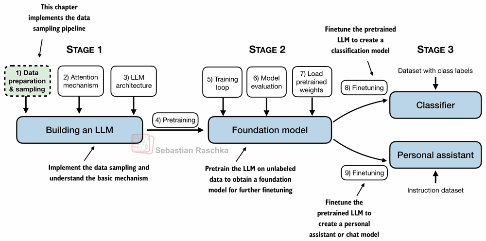

## 2.1 Entendendo word embeddings

- Não há código nesta seção
- Existem muitas formas de embeddings (representações vetoriais); neste livro, focamos em embeddings de texto

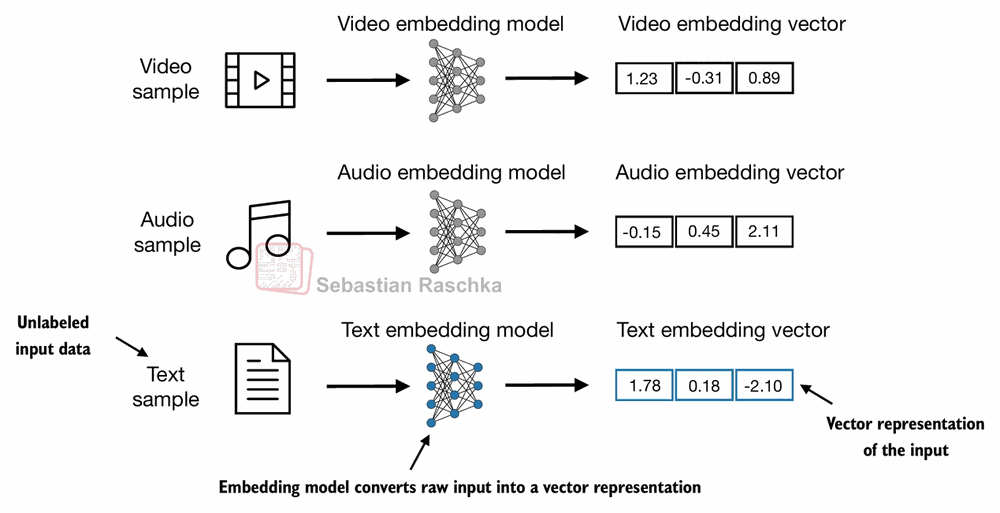

- LLMs trabalham com embeddings em espaços de alta dimensão (isto é, milhares de dimensões)
- Como não conseguimos visualizar espaços com tantas dimensões (nós, humanos, pensamos em 1, 2 ou 3 dimensões), a figura abaixo ilustra um espaço de embeddings bidimensional

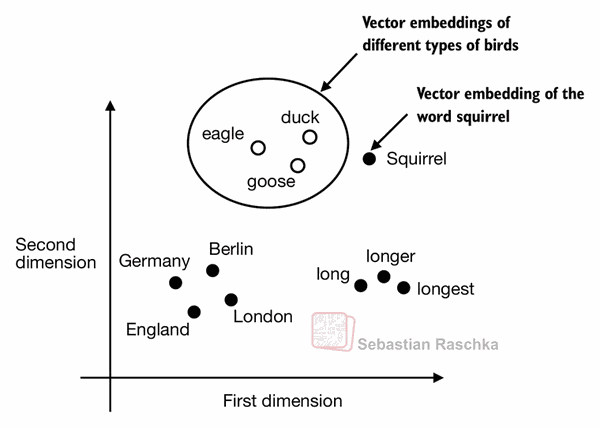

## 2.2 Tokenizando o texto

- Nesta seção, vamos tokenizar o texto, ou seja, quebrá-lo em unidades menores, como palavras individuais e caracteres de pontuação

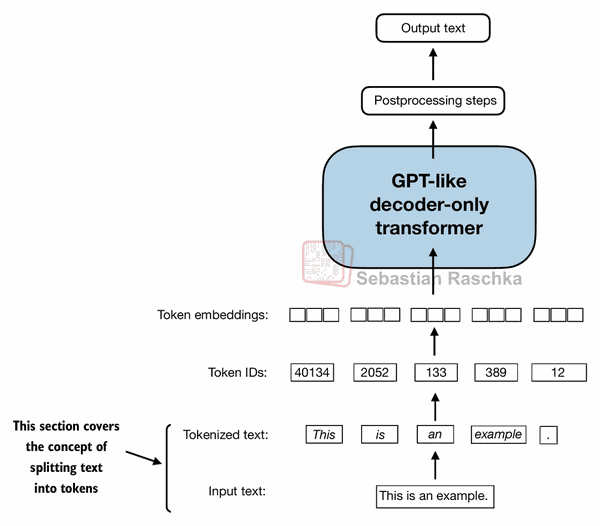

- Carregamos o texto bruto com o qual queremos trabalhar
- [The Verdict, de Edith Wharton](https://en.wikisource.org/wiki/The_Verdict), é um conto em domínio público

> 🇧🇷 **O que esta célula faz:** Carrega o conto de exemplo e mostra quantos caracteres ele tem, além do seu trecho inicial.

```python
with open("the-verdict.txt", "r", encoding="utf-8") as f:
    raw_text = f.read()

print("Total number of character:", len(raw_text))
print(raw_text[:99])
```

```
Total number of character: 20479
I HAD always thought Jack Gisburn rather a cheap genius--though a good fellow enough--so it was no
```

- O objetivo é tokenizar e gerar embeddings deste texto para um LLM
- Vamos desenvolver um tokenizer simples a partir de um pequeno texto de exemplo, que depois poderemos aplicar ao texto acima
- A expressão regular a seguir divide o texto nos espaços em branco

> 🇧🇷 **O que esta célula faz:** Divide uma frase de teste nos espaços em branco; a pontuação ainda fica grudada nas palavras.

```python
import re

text = "Hello, world. This, is a test."
result = re.split(r'(\s)', text)

print(result)
```

```
['Hello,', ' ', 'world.', ' ', 'This,', ' ', 'is', ' ', 'a', ' ', 'test.']
```

- Não queremos dividir apenas nos espaços em branco, mas também nas vírgulas e nos pontos; então vamos modificar a expressão regular para fazer isso também

> 🇧🇷 **O que esta célula faz:** Divide a frase também em vírgulas e pontos; a saída ainda contém espaços e strings vazias.

```python
result = re.split(r'([,.]|\s)', text)

print(result)
```

```
['Hello', ',', '', ' ', 'world', '.', '', ' ', 'This', ',', '', ' ', 'is', ' ', 'a', ' ', 'test', '.', '']
```

> 🇧🇷 **O que esta célula faz:** Remove os espaços e as strings vazias, deixando apenas palavras e pontuação.

```python
# Strip whitespace from each item and then filter out any empty strings.
result = [item for item in result if item.strip()]
print(result)
```

```
['Hello', ',', 'world', '.', 'This', ',', 'is', 'a', 'test', '.']
```

> 🇧🇷 **O que esta célula faz:** Aplica uma divisão mais completa, que reconhece vários sinais de pontuação, e mostra os tokens resultantes.

```python
text = "Hello, world. Is this-- a test?"

result = re.split(r'([,.:;?_!"()\']|--|\s)', text)
result = [item.strip() for item in result if item.strip()]
print(result)
```

```
['Hello', ',', 'world', '.', 'Is', 'this', '--', 'a', 'test', '?']
```

- Isso está muito bom, e agora estamos prontos para aplicar essa tokenização ao texto bruto

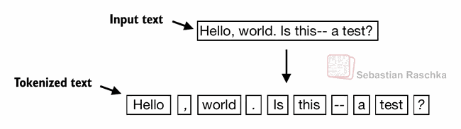

> 🇧🇷 **O que esta célula faz:** Tokeniza o conto inteiro e mostra os 30 primeiros tokens obtidos.

```python
preprocessed = re.split(r'([,.?_!"()\']|--|\s)', raw_text)
preprocessed = [item.strip() for item in preprocessed if item.strip()]
print(preprocessed[:30])
```

```
['I', 'HAD', 'always', 'thought', 'Jack', 'Gisburn', 'rather', 'a', 'cheap', 'genius', '--', 'though', 'a', 'good', 'fellow', 'enough', '--', 'so', 'it', 'was', 'no', 'great', 'surprise', 'to', 'me', 'to', 'hear', 'that', ',', 'in']
```

- Vamos calcular o número total de tokens

> 🇧🇷 **O que esta célula faz:** Mostra o número total de tokens do texto.

```python
print(len(preprocessed))
```

```
4649
```

## 2.3 Convertendo tokens em token IDs

- Em seguida, convertemos os tokens de texto em token IDs (identificadores numéricos), que depois poderemos processar por meio de camadas de embedding

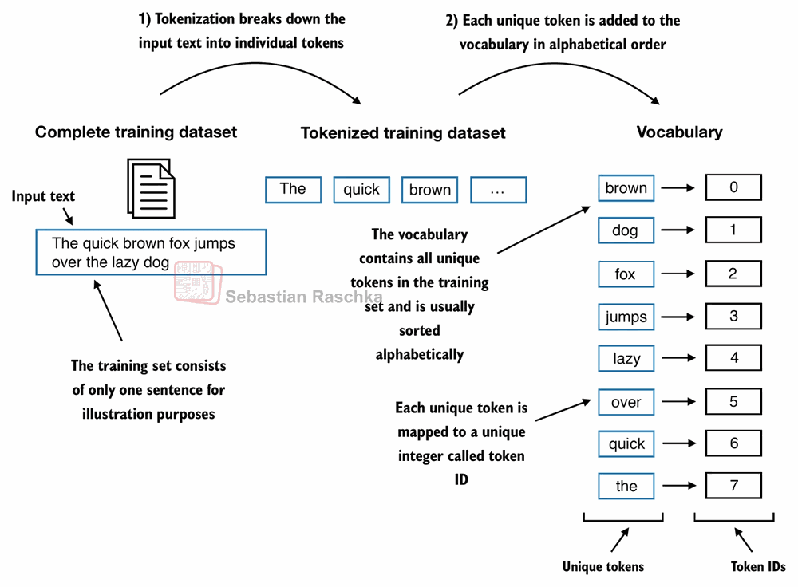

- A partir desses tokens, podemos agora construir um vocabulário formado por todos os tokens únicos

> 🇧🇷 **O que esta célula faz:** Reúne os tokens únicos em ordem alfabética e mostra o tamanho do vocabulário.

```python
all_words = sorted(list(set(preprocessed)))
vocab_size = len(all_words)

print(vocab_size)
```

```
1159
```

> 🇧🇷 **O que esta célula faz:** Cria o vocabulário, associando cada token a um número inteiro.

```python
vocab = {token:integer for integer,token in enumerate(all_words)}
```

- Abaixo estão as primeiras 50 entradas deste vocabulário:

> 🇧🇷 **O que esta célula faz:** Mostra as primeiras entradas do vocabulário: cada token com seu ID.

```python
for i, item in enumerate(vocab.items()):
    print(item)
    if i >= 50:
        break
```

```
('!', 0)
('"', 1)
("'", 2)
('(', 3)
(')', 4)
(',', 5)
('--', 6)
('.', 7)
(':', 8)
(';', 9)
('?', 10)
('A', 11)
('Ah', 12)
('Among', 13)
('And', 14)
('Are', 15)
('Arrt', 16)
('As', 17)
('At', 18)
('Be', 19)
('Begin', 20)
('Burlington', 21)
('But', 22)
('By', 23)
('Carlo', 24)
('Carlo;', 25)
('Chicago', 26)
('Claude', 27)
('Come', 28)
('Croft', 29)
('Destroyed', 30)
('Devonshire', 31)
('Don', 32)
('Dubarry', 33)
('Emperors', 34)
('Florence', 35)
('For', 36)
('Gallery', 37)
('Gideon', 38)
('Gisburn', 39)
('Gisburns', 40)
('Grafton', 41)
('Greek', 42)
('Grindle', 43)
('Grindle:', 44)
('Grindles', 45)
('HAD', 46)
('Had', 47)
('Hang', 48)
('Has', 49)
('He', 50)
```

- A seguir, ilustramos a tokenização de um pequeno texto de exemplo usando um vocabulário reduzido:

[figure not shown]

- Juntando tudo agora em uma classe de tokenizer

> 🇧🇷 **O que esta célula faz:** Define um tokenizer simples, capaz de converter texto em IDs e IDs de volta em texto.

```python
class SimpleTokenizerV1:
    def __init__(self, vocab):
        self.str_to_int = vocab
        self.int_to_str = {i:s for s,i in vocab.items()}

    def encode(self, text):
        preprocessed = re.split(r'([,.?_!"()\']|--|\s)', text)
        preprocessed = [item.strip() for item in preprocessed if item.strip()]
        ids = [self.str_to_int[s] for s in preprocessed]
        return ids

    def decode(self, ids):
        text = " ".join([self.int_to_str[i] for i in ids])
        # Replace spaces before the specified punctuations
        text = re.sub(r'\s+([,.?!"()\'])', r'\1', text)
        return text
```

- A função `encode` transforma texto em token IDs
- A função `decode` transforma token IDs de volta em texto

[figure not shown]

- Podemos usar o tokenizer para codificar (isto é, tokenizar) textos em números inteiros
- Esses inteiros poderão então (mais adiante) ser convertidos em embeddings e usados como entrada do LLM

> 🇧🇷 **O que esta célula faz:** Usa o tokenizer para converter uma frase do conto em uma lista de token IDs.

```python
tokenizer = SimpleTokenizerV1(vocab)

text = """"It's the last he painted, you know," Mrs. Gisburn said with pardonable pride."""
ids = tokenizer.encode(text)
print(ids)
```

```
[1, 58, 2, 872, 1013, 615, 541, 763, 5, 1155, 608, 5, 1, 69, 7, 39, 873, 1136, 773, 812, 7]
```

- Podemos decodificar os inteiros de volta em texto

> 🇧🇷 **O que esta célula faz:** Converte os IDs de volta em texto, recuperando a frase original.

```python
tokenizer.decode(ids)
```

```
'" It\' s the last he painted, you know," Mrs. Gisburn said with pardonable pride.'
```

> 🇧🇷 **O que esta célula faz:** Codifica e decodifica o texto em sequência, mostrando que o processo é reversível.

```python
tokenizer.decode(tokenizer.encode(text))
```

```
'" It\' s the last he painted, you know," Mrs. Gisburn said with pardonable pride.'
```

## 2.4 Adicionando tokens especiais de contexto

- É útil adicionar alguns tokens "especiais" para palavras desconhecidas e para indicar o fim de um texto

[figure not shown]

- Alguns tokenizers usam tokens especiais para fornecer contexto adicional ao LLM
- Alguns desses tokens especiais são
  - `[BOS]` (beginning of sequence, início da sequência) marca o início do texto
  - `[EOS]` (end of sequence, fim da sequência) marca onde o texto termina (geralmente é usado para concatenar vários textos não relacionados, por exemplo, dois artigos diferentes da Wikipédia, dois livros diferentes e assim por diante)
  - `[PAD]` (padding, preenchimento) se treinarmos LLMs com um batch size (tamanho de lote) maior que 1 (podemos incluir vários textos de comprimentos diferentes; com o token de padding, completamos os textos mais curtos até o comprimento do mais longo, para que todos tenham o mesmo tamanho)
- `[UNK]` para representar palavras que não estão incluídas no vocabulário
- Observe que o GPT-2 não precisa de nenhum dos tokens mencionados acima, usando apenas um token `<|endoftext|>` para reduzir a complexidade
- O `<|endoftext|>` é análogo ao token `[EOS]` mencionado acima
- O GPT também usa o `<|endoftext|>` para padding (como normalmente usamos uma máscara ao treinar com entradas em batches, os tokens de preenchimento não recebem atenção de qualquer forma, então não importa quais tokens sejam esses)
- O GPT-2 não usa um token `<UNK>` para palavras fora do vocabulário; em vez disso, o GPT-2 usa um tokenizer de byte pair encoding (BPE), que quebra as palavras em unidades de subpalavras, que discutiremos em uma seção posterior
- Usamos os tokens `<|endoftext|>` entre duas fontes de texto independentes:

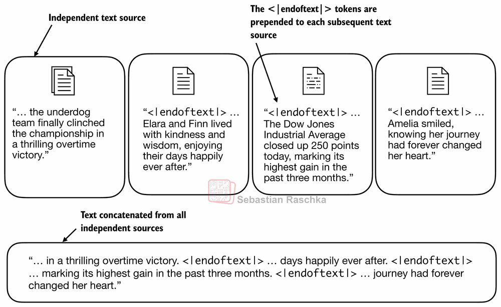

- Vejamos o que acontece se tokenizarmos o texto a seguir:

> 🇧🇷 **O que esta célula faz:** Tenta tokenizar uma frase com palavras fora do vocabulário, o que gera um erro.

```python
tokenizer = SimpleTokenizerV1(vocab)

text = "Hello, do you like tea. Is this-- a test?"

tokenizer.encode(text)
```

```
---------------------------------------------------------------------------
KeyError                                  Traceback (most recent call last)
Cell In[20], line 5
      1 tokenizer = SimpleTokenizerV1(vocab)
      3 text = "Hello, do you like tea. Is this-- a test?"
----> 5 tokenizer.encode(text)

Cell In[16], line 9, in SimpleTokenizerV1.encode(self, text)
      7 preprocessed = re.split(r'([,.?_!"()\']|--|\s)', text)
      8 preprocessed = [item.strip() for item in preprocessed if item.strip()]
----> 9 ids = [self.str_to_int[s] for s in preprocessed]
     10 return ids

Cell In[16], line 9, in <listcomp>(.0)
      7 preprocessed = re.split(r'([,.?_!"()\']|--|\s)', text)
      8 preprocessed = [item.strip() for item in preprocessed if item.strip()]
----> 9 ids = [self.str_to_int[s] for s in preprocessed]
     10 return ids

KeyError: 'Hello'
```

- O código acima produz um erro porque a palavra "Hello" não está contida no vocabulário
- Para lidar com esses casos, podemos adicionar ao vocabulário tokens especiais como `"<|unk|>"`, para representar palavras desconhecidas
- Já que estamos ampliando o vocabulário, vamos adicionar outro token, chamado `"<|endoftext|>"`, que é usado no treinamento do GPT-2 para indicar o fim de um texto (e também é usado entre textos concatenados, por exemplo, quando nosso conjunto de dados de treinamento é formado por vários artigos, livros etc.)

> 🇧🇷 **O que esta célula faz:** Reconstrói o vocabulário acrescentando os tokens especiais de fim de texto e de palavra desconhecida.

```python
preprocessed = re.split(r'([,.?_!"()\']|--|\s)', raw_text)
preprocessed = [item.strip() for item in preprocessed if item.strip()]

all_tokens = sorted(list(set(preprocessed)))
all_tokens.extend(["<|endoftext|>", "<|unk|>"])

vocab = {token:integer for integer,token in enumerate(all_tokens)}
```

> 🇧🇷 **O que esta célula faz:** Mostra o novo tamanho do vocabulário, agora com dois tokens a mais.

```python
len(vocab.items())
```

```
1161
```

> 🇧🇷 **O que esta célula faz:** Mostra as últimas entradas do vocabulário, onde aparecem os dois tokens especiais.

```python
for i, item in enumerate(list(vocab.items())[-5:]):
    print(item)
```

```
('younger', 1156)
('your', 1157)
('yourself', 1158)
('<|endoftext|>', 1159)
('<|unk|>', 1160)
```

- Também precisamos ajustar o tokenizer para que ele saiba quando e como usar o novo token `<unk>`

> 🇧🇷 **O que esta célula faz:** Define uma nova versão do tokenizer que substitui palavras desconhecidas por um token especial.

```python
class SimpleTokenizerV2:
    def __init__(self, vocab):
        self.str_to_int = vocab
        self.int_to_str = { i:s for s,i in vocab.items()}

    def encode(self, text):
        preprocessed = re.split(r'([,.?_!"()\']|--|\s)', text)
        preprocessed = [item.strip() for item in preprocessed if item.strip()]
        preprocessed = [item if item in self.str_to_int
                        else "<|unk|>" for item in preprocessed]

        ids = [self.str_to_int[s] for s in preprocessed]
        return ids

    def decode(self, ids):
        text = " ".join([self.int_to_str[i] for i in ids])
        # Replace spaces before the specified punctuations
        text = re.sub(r'\s+([,.?!"()\'])', r'\1', text)
        return text
```

Vamos tentar tokenizar um texto com o tokenizer modificado:

> 🇧🇷 **O que esta célula faz:** Junta duas frases independentes, separadas pelo token de fim de texto, e mostra o resultado.

```python
tokenizer = SimpleTokenizerV2(vocab)

text1 = "Hello, do you like tea?"
text2 = "In the sunlit terraces of the palace."

text = " <|endoftext|> ".join((text1, text2))

print(text)
```

```
Hello, do you like tea? <|endoftext|> In the sunlit terraces of the palace.
```

> 🇧🇷 **O que esta célula faz:** Converte o texto combinado em token IDs; palavras desconhecidas recebem o ID do token especial.

```python
tokenizer.encode(text)
```

```
[1160,
 5,
 362,
 1155,
 642,
 1000,
 10,
 1159,
 57,
 1013,
 981,
 1009,
 738,
 1013,
 1160,
 7]
```

> 🇧🇷 **O que esta célula faz:** Decodifica os IDs de volta em texto: as palavras desconhecidas aparecem como o token especial.

```python
tokenizer.decode(tokenizer.encode(text))
```

```
'<|unk|>, do you like tea? <|endoftext|> In the sunlit terraces of the <|unk|>.'
```

## 2.5 Byte pair encoding

- O GPT-2 usou o byte pair encoding (BPE, codificação por pares de bytes) como tokenizer
- Ele permite que o modelo quebre palavras que não estão em seu vocabulário predefinido em unidades menores de subpalavras ou até em caracteres individuais, o que lhe permite lidar com palavras fora do vocabulário
- Por exemplo, se o vocabulário do GPT-2 não tiver a palavra "unfamiliarword", ele pode tokenizá-la como ["unfam", "iliar", "word"] ou alguma outra divisão em subpalavras, dependendo das fusões (merges) de BPE aprendidas no treinamento
- O tokenizer BPE original pode ser encontrado aqui: https://github.com/openai/gpt-2/blob/master/src/encoder.py
- Neste capítulo, usamos o tokenizer BPE da biblioteca de código aberto tiktoken, da OpenAI, que implementa seus algoritmos principais em Rust para melhorar o desempenho computacional
- Criei um notebook em ./bytepair_encoder que compara essas duas implementações lado a lado (o tiktoken foi cerca de 5x mais rápido no texto de exemplo)

> 🇧🇷 **O que esta célula faz:** Comentário lembrando como instalar o tiktoken; não executa nada.

```python
# pip install tiktoken
```

> 🇧🇷 **O que esta célula faz:** Importa o tiktoken e mostra a versão instalada.

```python
import importlib
import tiktoken

print("tiktoken version:", importlib.metadata.version("tiktoken"))
```

```
tiktoken version: 0.7.0
```

> 🇧🇷 **O que esta célula faz:** Carrega o tokenizer BPE usado pelo GPT-2.

```python
tokenizer = tiktoken.get_encoding("gpt2")
```

> 🇧🇷 **O que esta célula faz:** Codifica um texto com o tokenizer BPE; até uma palavra inventada é convertida em IDs, sem erro.

```python
text = "Hello, do you like tea? <|endoftext|> In the sunlit terraces of someunknownPlace."

integers = tokenizer.encode(text, allowed_special={"<|endoftext|>"})

print(integers)
```

```
[15496, 11, 466, 345, 588, 8887, 30, 220, 50256, 554, 262, 4252, 18250, 8812, 2114, 286, 617, 34680, 27271, 13]
```

> 🇧🇷 **O que esta célula faz:** Decodifica os IDs e recupera exatamente o texto original.

```python
strings = tokenizer.decode(integers)

print(strings)
```

```
Hello, do you like tea? <|endoftext|> In the sunlit terraces of someunknownPlace.
```

- Tokenizers BPE quebram palavras desconhecidas em subpalavras e caracteres individuais:

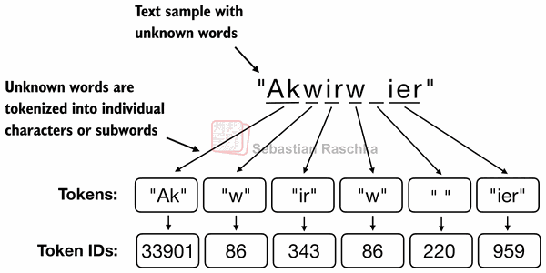

## 2.6 Amostragem de dados com janela deslizante

- Treinamos LLMs para gerar uma palavra por vez; por isso, queremos preparar os dados de treinamento de modo que a próxima palavra de uma sequência represente o alvo a ser previsto:

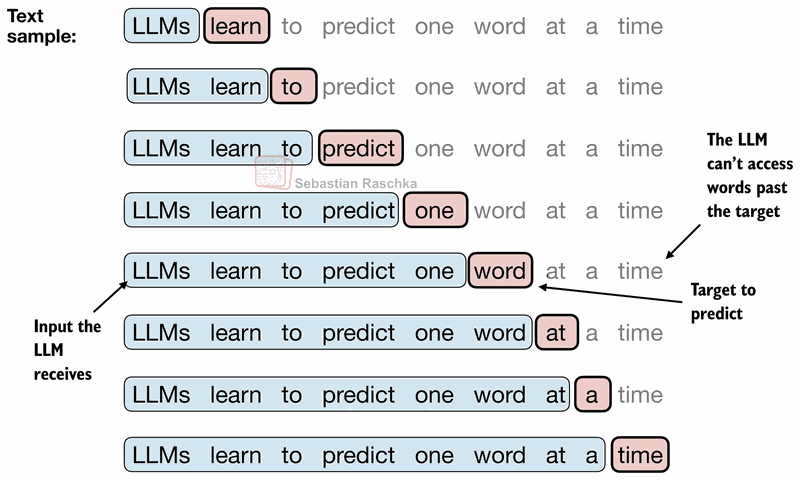

> 🇧🇷 **O que esta célula faz:** Tokeniza o conto inteiro com o BPE e mostra quantos tokens ele gera.

```python
with open("the-verdict.txt", "r", encoding="utf-8") as f:
    raw_text = f.read()

enc_text = tokenizer.encode(raw_text)
print(len(enc_text))
```

```
5145
```

- Para cada trecho de texto, queremos as entradas e os alvos
- Como queremos que o modelo preveja a próxima palavra, os alvos são as entradas deslocadas uma posição para a direita

> 🇧🇷 **O que esta célula faz:** Separa uma amostra do texto tokenizado, a partir da posição 50.

```python
enc_sample = enc_text[50:]
```

> 🇧🇷 **O que esta célula faz:** Monta um par de entrada e alvo, em que o alvo é a entrada deslocada uma posição.

```python
context_size = 4

x = enc_sample[:context_size]
y = enc_sample[1:context_size+1]

print(f"x: {x}")
print(f"y:      {y}")
```

```
x: [290, 4920, 2241, 287]
y:      [4920, 2241, 287, 257]
```

- Passo a passo, a previsão ficaria assim:

> 🇧🇷 **O que esta célula faz:** Mostra, passo a passo, qual token o modelo deve prever a partir de cada contexto.

```python
for i in range(1, context_size+1):
    context = enc_sample[:i]
    desired = enc_sample[i]

    print(context, "---->", desired)
```

```
[290] ----> 4920
[290, 4920] ----> 2241
[290, 4920, 2241] ----> 287
[290, 4920, 2241, 287] ----> 257
```

> 🇧🇷 **O que esta célula faz:** Repete a demonstração anterior, agora mostrando os tokens como texto legível.

```python
for i in range(1, context_size+1):
    context = enc_sample[:i]
    desired = enc_sample[i]

    print(tokenizer.decode(context), "---->", tokenizer.decode([desired]))
```

```
 and ---->  established
 and established ---->  himself
 and established himself ---->  in
 and established himself in ---->  a
```

- Cuidaremos da previsão da próxima palavra em um capítulo posterior, depois de estudarmos o mecanismo de atenção
- Por enquanto, implementamos um data loader simples, que percorre o conjunto de dados de entrada e retorna as entradas e os alvos deslocados em uma posição
- Instale e importe o PyTorch (veja o Apêndice A para dicas de instalação)

> 🇧🇷 **O que esta célula faz:** Importa o PyTorch e mostra sua versão.

```python
import torch
print("PyTorch version:", torch.__version__)
```

```
PyTorch version: 2.3.1+cu121
```

- Usamos uma abordagem de janela deslizante, avançando a posição em +1:

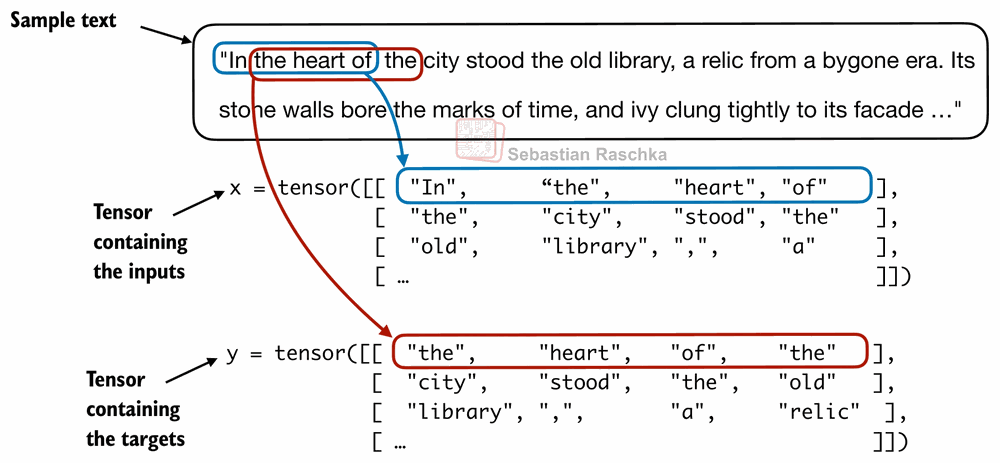

- Criamos um dataset e um dataloader que extraem trechos do conjunto de dados de texto de entrada

> 🇧🇷 **O que esta célula faz:** Define um dataset que percorre o texto com uma janela deslizante, gerando pares de entrada e alvo.

```python
from torch.utils.data import Dataset, DataLoader


class GPTDatasetV1(Dataset):
    def __init__(self, txt, tokenizer, max_length, stride):
        self.input_ids = []
        self.target_ids = []

        # Tokenize the entire text
        token_ids = tokenizer.encode(txt, allowed_special={"<|endoftext|>"})

        # Use a sliding window to chunk the book into overlapping sequences of max_length
        for i in range(0, len(token_ids) - max_length, stride):
            input_chunk = token_ids[i:i + max_length]
            target_chunk = token_ids[i + 1: i + max_length + 1]
            self.input_ids.append(torch.tensor(input_chunk))
            self.target_ids.append(torch.tensor(target_chunk))

    def __len__(self):
        return len(self.input_ids)

    def __getitem__(self, idx):
        return self.input_ids[idx], self.target_ids[idx]
```

> 🇧🇷 **O que esta célula faz:** Define uma função que cria um dataloader a partir do texto, com tamanho de batch, contexto e stride configuráveis.

```python
def create_dataloader_v1(txt, batch_size=4, max_length=256, stride=128, shuffle=True, drop_last=True, num_workers=0):

    # Initialize the tokenizer
    tokenizer = tiktoken.get_encoding("gpt2")

    # Create dataset
    dataset = GPTDatasetV1(txt, tokenizer, max_length, stride)

    # Create dataloader
    dataloader = DataLoader(
        dataset,
        batch_size=batch_size,
        shuffle=shuffle,
        drop_last=drop_last,
        num_workers=0
    )

    return dataloader
```

- Vamos testar o dataloader com um batch size de 1 para um LLM com tamanho de contexto 4:

> 🇧🇷 **O que esta célula faz:** Carrega novamente o texto do conto.

```python
with open("the-verdict.txt", "r", encoding="utf-8") as f:
    raw_text = f.read()
```

> 🇧🇷 **O que esta célula faz:** Cria um dataloader com contexto 4 e stride 1 e mostra o primeiro batch: entradas e alvos.

```python
dataloader = create_dataloader_v1(raw_text, batch_size=1, max_length=4, stride=1, shuffle=False)

data_iter = iter(dataloader)
first_batch = next(data_iter)
print(first_batch)
```

```
[tensor([[  40,  367, 2885, 1464]]), tensor([[ 367, 2885, 1464, 1807]])]
```

> 🇧🇷 **O que esta célula faz:** Mostra o segundo batch: a janela avançou uma posição.

```python
second_batch = next(data_iter)
print(second_batch)
```

```
[tensor([[ 367, 2885, 1464, 1807]]), tensor([[2885, 1464, 1807, 3619]])]
```

- Um exemplo usando stride (passo) igual ao comprimento do contexto (aqui: 4) é mostrado abaixo:

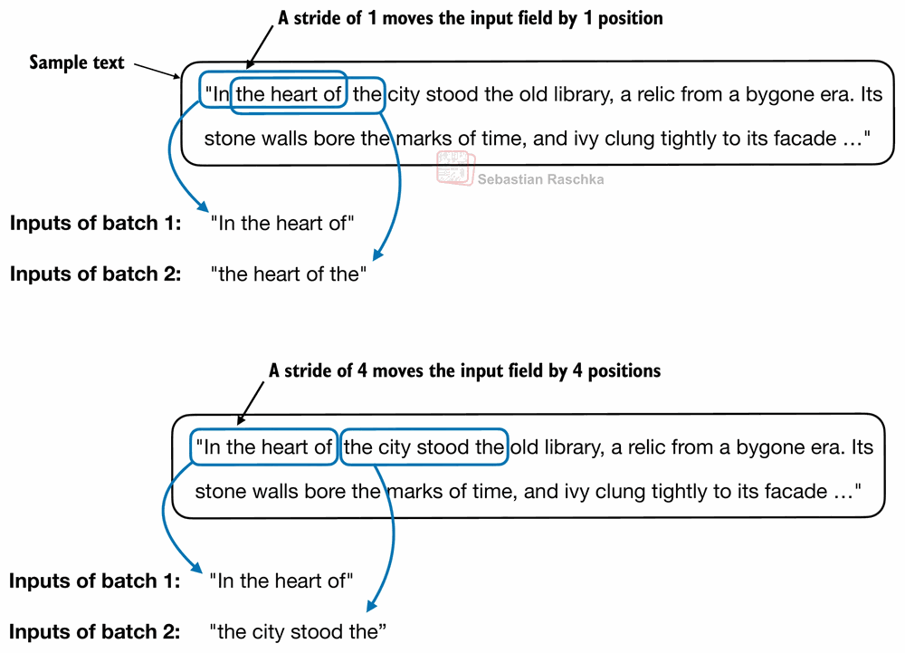

- Também podemos criar saídas em batches
- Observe que aqui aumentamos o stride para que não haja sobreposição entre os batches, já que mais sobreposição poderia levar a um overfitting (sobreajuste) maior

> 🇧🇷 **O que esta célula faz:** Cria batches de 8 exemplos sem sobreposição e mostra as entradas e os alvos correspondentes.

```python
dataloader = create_dataloader_v1(raw_text, batch_size=8, max_length=4, stride=4, shuffle=False)

data_iter = iter(dataloader)
inputs, targets = next(data_iter)
print("Inputs:\n", inputs)
print("\nTargets:\n", targets)
```

```
Inputs:
 tensor([[   40,   367,  2885,  1464],
        [ 1807,  3619,   402,   271],
        [10899,  2138,   257,  7026],
        [15632,   438,  2016,   257],
        [  922,  5891,  1576,   438],
        [  568,   340,   373,   645],
        [ 1049,  5975,   284,   502],
        [  284,  3285,   326,    11]])

Targets:
 tensor([[  367,  2885,  1464,  1807],
        [ 3619,   402,   271, 10899],
        [ 2138,   257,  7026, 15632],
        [  438,  2016,   257,   922],
        [ 5891,  1576,   438,   568],
        [  340,   373,   645,  1049],
        [ 5975,   284,   502,   284],
        [ 3285,   326,    11,   287]])
```

## 2.7 Criando embeddings de tokens

- Os dados já estão quase prontos para um LLM
- Mas, por último, vamos converter os tokens em uma representação vetorial contínua usando uma camada de embedding
- Normalmente, essas camadas de embedding fazem parte do próprio LLM e são atualizadas (treinadas) durante o treinamento do modelo

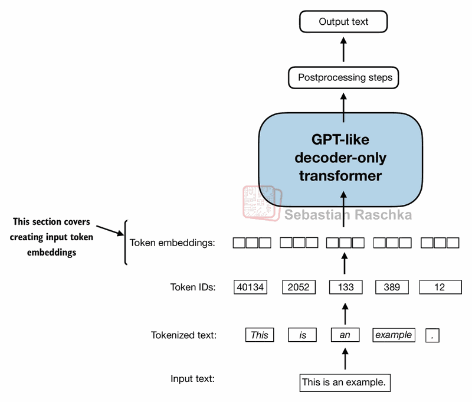

> 🇧🇷 **O que esta célula faz:** Define quatro token IDs de exemplo.

```python
input_ids = torch.tensor([2, 3, 5, 1])
```

- Para simplificar, suponha que temos um vocabulário pequeno, com apenas 6 palavras, e queremos criar embeddings de tamanho 3:

> 🇧🇷 **O que esta célula faz:** Cria uma camada de embedding para um vocabulário de 6 tokens, com vetores de 3 dimensões.

```python
vocab_size = 6
output_dim = 3

torch.manual_seed(123)
embedding_layer = torch.nn.Embedding(vocab_size, output_dim)
```

- Isso resultaria em uma matriz de pesos de 6x3:

> 🇧🇷 **O que esta célula faz:** Mostra a matriz de pesos da camada de embedding, inicializada aleatoriamente.

```python
print(embedding_layer.weight)
```

```
Parameter containing:
tensor([[ 0.3374, -0.1778, -0.1690],
        [ 0.9178,  1.5810,  1.3010],
        [ 1.2753, -0.2010, -0.1606],
        [-0.4015,  0.9666, -1.1481],
        [-1.1589,  0.3255, -0.6315],
        [-2.8400, -0.7849, -1.4096]], requires_grad=True)
```

- Para quem conhece one-hot encoding, a abordagem da camada de embedding acima é basicamente apenas uma forma mais eficiente de implementar one-hot encoding seguido de uma multiplicação de matrizes em uma camada totalmente conectada, como descrito no código complementar em ./embedding_vs_matmul
- Como a camada de embedding é apenas uma implementação mais eficiente, equivalente à abordagem de one-hot encoding com multiplicação de matrizes, ela pode ser vista como uma camada de rede neural que pode ser otimizada via backpropagation (retropropagação)
- Para converter um token com ID 3 em um vetor de 3 dimensões, fazemos o seguinte:

> 🇧🇷 **O que esta célula faz:** Obtém o vetor de embedding do token de ID 3, que é uma linha da matriz de pesos.

```python
print(embedding_layer(torch.tensor([3])))
```

```
tensor([[-0.4015,  0.9666, -1.1481]], grad_fn=<EmbeddingBackward0>)
```

- Observe que o resultado acima é a 4ª linha da matriz de pesos da `embedding_layer`
- Para gerar os embeddings dos quatro valores de `input_ids` acima, fazemos

> 🇧🇷 **O que esta célula faz:** Obtém os vetores de embedding dos quatro IDs de exemplo de uma só vez.

```python
print(embedding_layer(input_ids))
```

```
tensor([[ 1.2753, -0.2010, -0.1606],
        [-0.4015,  0.9666, -1.1481],
        [-2.8400, -0.7849, -1.4096],
        [ 0.9178,  1.5810,  1.3010]], grad_fn=<EmbeddingBackward0>)
```

- Uma camada de embedding é, essencialmente, uma operação de consulta (look-up):

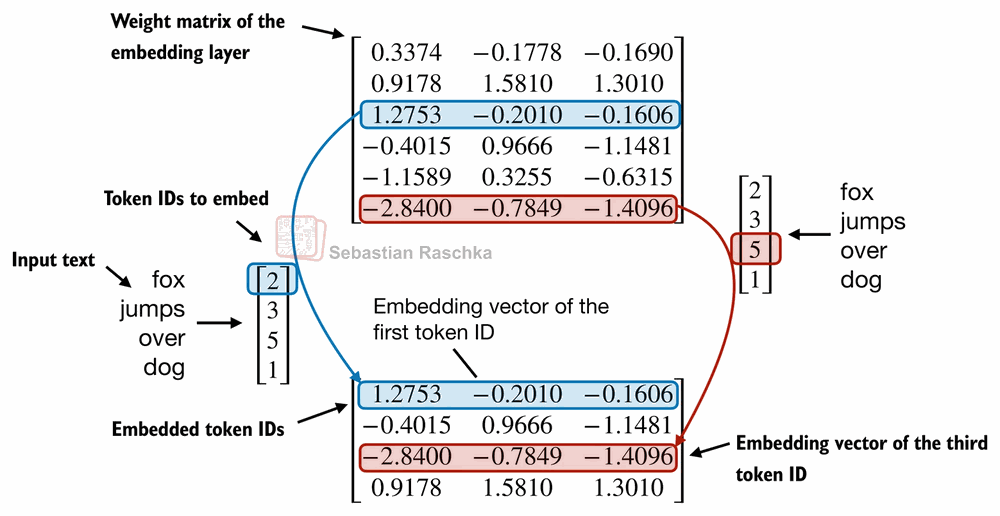

- **Talvez você se interesse pelo conteúdo bônus que compara camadas de embedding com camadas lineares comuns: ../03_bonus_embedding-vs-matmul**

## 2.8 Codificando as posições das palavras

- A camada de embedding converte IDs em representações vetoriais idênticas, independentemente de onde eles estejam na sequência de entrada:

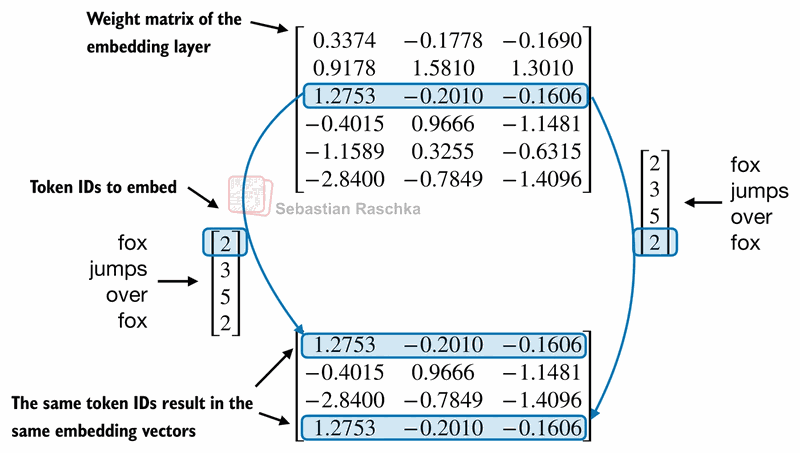

- Os embeddings de posição são combinados com o vetor de embedding do token para formar os embeddings de entrada de um modelo de linguagem de grande porte:

[figure not shown]

- O codificador BytePair tem um vocabulário de 50.257 tokens:
- Suponha que queremos codificar os tokens de entrada em uma representação vetorial de 256 dimensões:

> 🇧🇷 **O que esta célula faz:** Cria a camada de embedding de tokens com o vocabulário do GPT-2 e vetores de 256 dimensões.

```python
vocab_size = 50257
output_dim = 256

token_embedding_layer = torch.nn.Embedding(vocab_size, output_dim)
```

- Se amostrarmos dados do dataloader, convertemos os tokens de cada batch em vetores de 256 dimensões
- Se tivermos um batch size de 8, com 4 tokens cada, isso resulta em um tensor de 8 x 4 x 256:

> 🇧🇷 **O que esta célula faz:** Cria um dataloader com batches de 8 sequências de 4 tokens e extrai o primeiro batch.

```python
max_length = 4
dataloader = create_dataloader_v1(raw_text, batch_size=8, max_length=max_length, stride=max_length, shuffle=False)
data_iter = iter(dataloader)
inputs, targets = next(data_iter)
```

> 🇧🇷 **O que esta célula faz:** Mostra os token IDs do batch e o formato do tensor de entrada.

```python
print("Token IDs:\n", inputs)
print("\nInputs shape:\n", inputs.shape)
```

```
Token IDs:
 tensor([[   40,   367,  2885,  1464],
        [ 1807,  3619,   402,   271],
        [10899,  2138,   257,  7026],
        [15632,   438,  2016,   257],
        [  922,  5891,  1576,   438],
        [  568,   340,   373,   645],
        [ 1049,  5975,   284,   502],
        [  284,  3285,   326,    11]])

Inputs shape:
 torch.Size([8, 4])
```

> 🇧🇷 **O que esta célula faz:** Converte os IDs do batch em embeddings e mostra o formato resultante: 8 x 4 x 256.

```python
token_embeddings = token_embedding_layer(inputs)
print(token_embeddings.shape)
```

```
torch.Size([8, 4, 256])
```

- O GPT-2 usa embeddings de posição absolutos, então basta criarmos outra camada de embedding:

> 🇧🇷 **O que esta célula faz:** Cria a camada de embeddings de posição, com uma posição para cada token do contexto.

```python
context_length = max_length
pos_embedding_layer = torch.nn.Embedding(context_length, output_dim)
```

> 🇧🇷 **O que esta célula faz:** Gera os embeddings das 4 posições e mostra seu formato.

```python
pos_embeddings = pos_embedding_layer(torch.arange(max_length))
print(pos_embeddings.shape)
```

```
torch.Size([4, 256])
```

- Para criar os embeddings de entrada usados em um LLM, simplesmente somamos os embeddings de token e os de posição:

> 🇧🇷 **O que esta célula faz:** Soma os embeddings de token e de posição, obtendo os embeddings de entrada do LLM.

```python
input_embeddings = token_embeddings + pos_embeddings
print(input_embeddings.shape)
```

```
torch.Size([8, 4, 256])
```

- Na fase inicial do fluxo de processamento da entrada, o texto de entrada é segmentado em tokens separados
- Após essa segmentação, esses tokens são transformados em token IDs com base em um vocabulário predefinido:

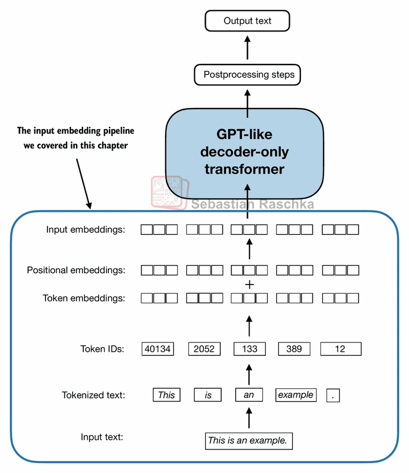

# Resumo e principais lições

**Veja o notebook ./dataloader.ipynb**, que é uma versão concisa do data loader que implementamos neste capítulo e do qual vamos precisar para treinar o modelo GPT nos próximos capítulos.

**Veja ./exercise-solutions.ipynb para as soluções dos exercícios.**

# Capítulo 3 — Implementando mecanismos de atenção

Neste capítulo, construímos o **mecanismo de atenção**, o coração dos LLMs. Partimos de uma versão simples de self-attention (autoatenção), sem pesos treináveis, para entender a ideia de vetores de contexto. Em seguida, adicionamos as matrizes treináveis de query, key e value, aplicamos a máscara causal (para que o modelo não "veja o futuro") e o dropout e, por fim, combinamos várias cabeças em uma **multi-head attention**.

No capítulo anterior, transformamos texto em embeddings; aqui, ensinamos o modelo a relacionar esses tokens entre si. O módulo `MultiHeadAttention` construído no final será uma peça central da arquitetura GPT que montaremos no próximo capítulo.

Código complementar do livro "Build a Large Language Model From Scratch": https://www.manning.com/books/build-a-large-language-model-from-scratch, de [Sebastian Raschka](https://sebastianraschka.com)  
Repositório do código: https://github.com/rasbt/LLMs-from-scratch

# Capítulo 3: Programando mecanismos de atenção

Pacotes usados neste notebook:

> 🇧🇷 **O que esta célula faz:** Mostra a versão do PyTorch instalada no ambiente.

```python
from importlib.metadata import version

print("torch version:", version("torch"))
```

```
torch version: 2.3.1
```

- Este capítulo trata dos mecanismos de atenção, o motor dos LLMs:

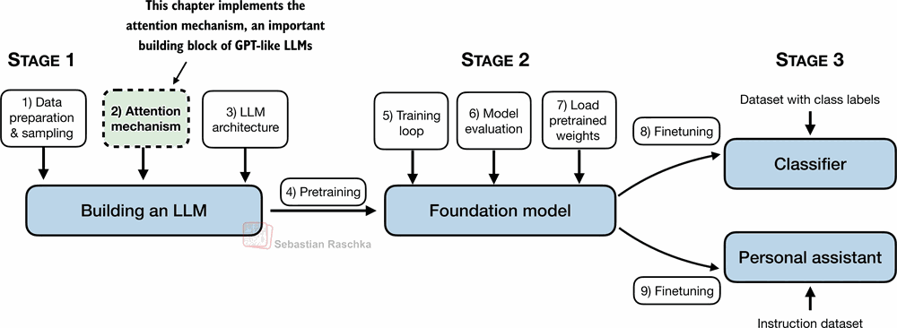

[figure not shown]

## 3.1 O problema de modelar sequências longas

- Não há código nesta seção
- Traduzir um texto palavra por palavra não é viável, por causa das diferenças entre as estruturas gramaticais do idioma de origem e do idioma de destino:

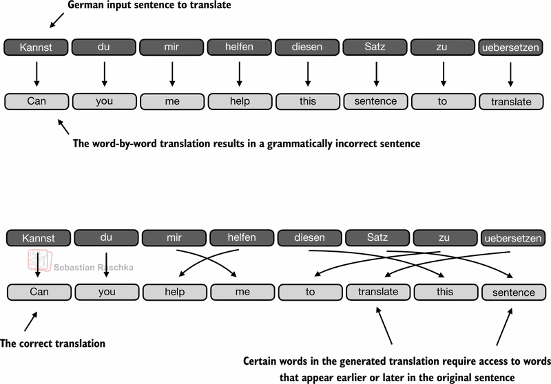

- Antes da introdução dos modelos transformer, RNNs (redes neurais recorrentes) do tipo encoder-decoder eram muito usadas em tarefas de tradução automática
- Nessa configuração, o encoder processa uma sequência de tokens do idioma de origem, usando um estado oculto (hidden state) — uma espécie de camada intermediária dentro da rede neural — para gerar uma representação condensada de toda a sequência de entrada:

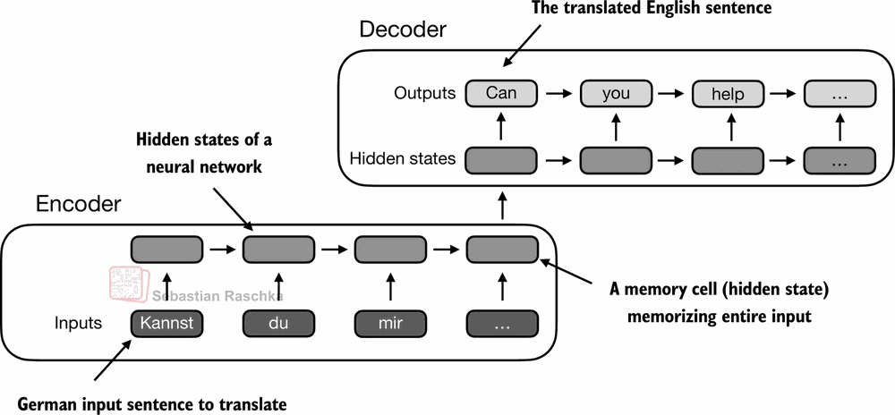

## 3.2 Capturando dependências nos dados com mecanismos de atenção

- Não há código nesta seção
- Por meio de um mecanismo de atenção, a parte decoder da rede, que gera o texto, consegue acessar seletivamente todos os tokens de entrada, o que significa que alguns tokens de entrada têm mais importância do que outros na geração de um determinado token de saída:

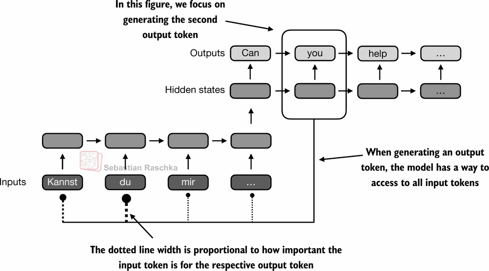

- A self-attention (autoatenção) nos transformers é uma técnica criada para enriquecer as representações da entrada, permitindo que cada posição de uma sequência interaja com todas as outras posições da mesma sequência e determine a relevância de cada uma delas

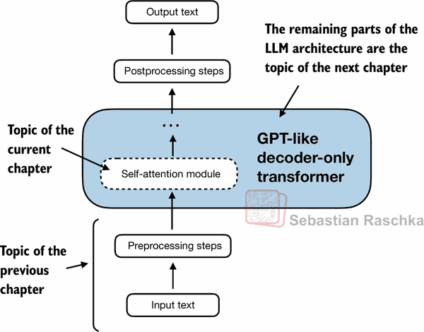

## 3.3 Prestando atenção a diferentes partes da entrada com self-attention

### 3.3.1 Um mecanismo simples de self-attention sem pesos treináveis

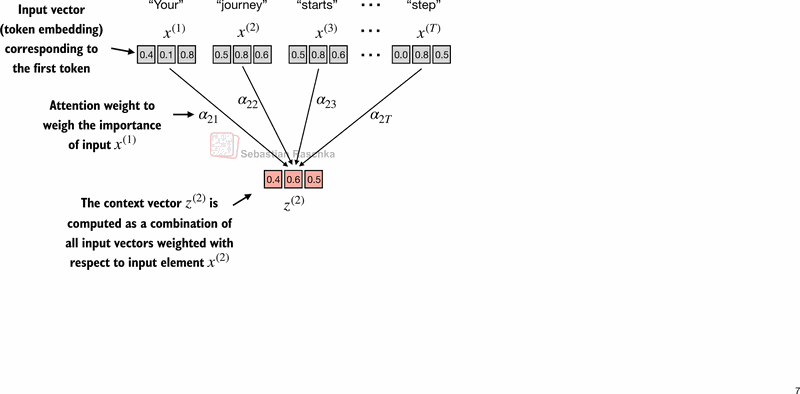

- Por convenção, os pesos de atenção não normalizados são chamados de **"attention scores"** (pontuações de atenção), enquanto as pontuações de atenção normalizadas, que somam 1, são chamadas de **"attention weights"** (pesos de atenção)
- O código abaixo percorre a figura acima passo a passo
- **Passo 1:** calcular as pontuações de atenção não normalizadas $\omega$
- Suponha que usamos o segundo token de entrada como query (consulta), ou seja, $q^{(2)} = x^{(2)}$; calculamos as pontuações de atenção não normalizadas por meio de produtos escalares (dot products):
  - $\omega_{21} = x^{(1)} q^{(2)\top}$
  - $\omega_{22} = x^{(2)} q^{(2)\top}$
  - $\omega_{23} = x^{(3)} q^{(2)\top}$
  - ...
  - $\omega_{2T} = x^{(T)} q^{(2)\top}$
- Acima, $\omega$ é a letra grega "ômega", usada para simbolizar as pontuações de atenção não normalizadas
  - O índice "21" em $\omega_{21}$ significa que o elemento 2 da sequência de entrada foi usado como query em relação ao elemento 1 da sequência de entrada
- Suponha que temos a seguinte frase de entrada, que já foi convertida em embeddings de 3 dimensões, como descrito no capítulo 2 (usamos aqui uma dimensão de embedding bem pequena para fins de ilustração, para que caiba na página sem quebras de linha):

> 🇧🇷 **O que esta célula faz:** Cria um pequeno tensor com a frase de exemplo: seis tokens, cada um representado por um embedding de 3 dimensões.

```python
import torch

inputs = torch.tensor(
  [[0.43, 0.15, 0.89], # Your     (x^1)
   [0.55, 0.87, 0.66], # journey  (x^2)
   [0.57, 0.85, 0.64], # starts   (x^3)
   [0.22, 0.58, 0.33], # with     (x^4)
   [0.77, 0.25, 0.10], # one      (x^5)
   [0.05, 0.80, 0.55]] # step     (x^6)
)
```

- O objetivo principal desta seção é demonstrar como o context vector $z^{(2)}$ é calculado usando a segunda entrada da sequência, $x^{(2)}$, como query
- A figura mostra o passo inicial desse processo, que consiste em calcular as pontuações de atenção ω entre $x^{(2)}$ e todos os outros elementos de entrada por meio de uma operação de produto escalar.

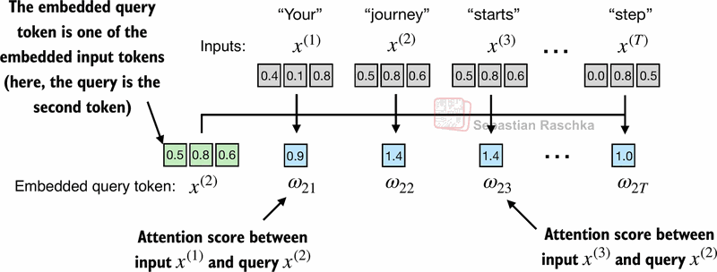

- Usamos o elemento 2 da sequência de entrada, $x^{(2)}$, como exemplo para calcular o context vector $z^{(2)}$; mais adiante nesta seção, vamos generalizar isso para calcular todos os context vectors.
- O primeiro passo é calcular as pontuações de atenção não normalizadas, fazendo o produto escalar entre a query $x^{(2)}$ e todos os outros tokens de entrada:

> 🇧🇷 **O que esta célula faz:** Usa o segundo token como query e calcula sua pontuação de atenção em relação a cada um dos seis tokens por meio de produtos escalares.

```python
query = inputs[1]  # 2nd input token is the query

attn_scores_2 = torch.empty(inputs.shape[0])
for i, x_i in enumerate(inputs):
    attn_scores_2[i] = torch.dot(x_i, query) # dot product (transpose not necessary here since they are 1-dim vectors)

print(attn_scores_2)
```

```
tensor([0.9544, 1.4950, 1.4754, 0.8434, 0.7070, 1.0865])
```

- Observação: um produto escalar é basicamente uma forma abreviada de multiplicar dois vetores elemento a elemento e somar os produtos resultantes:

> 🇧🇷 **O que esta célula faz:** Refaz um produto escalar manualmente, multiplicando e somando elemento a elemento, e confirma que o resultado é igual ao de torch.dot.

```python
res = 0.

for idx, element in enumerate(inputs[0]):
    res += inputs[0][idx] * query[idx]

print(res)
print(torch.dot(inputs[0], query))
```

```
tensor(0.9544)
tensor(0.9544)
```

- **Passo 2:** normalizar as pontuações de atenção não normalizadas ("ômegas", $\omega$) para que somem 1
- Veja uma forma simples de normalizar as pontuações de atenção para que somem 1 (uma convenção útil para a interpretação e importante para a estabilidade do treinamento):

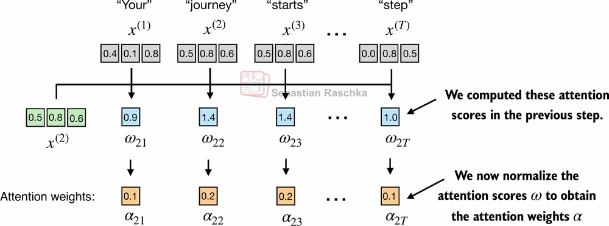

> 🇧🇷 **O que esta célula faz:** Normaliza as pontuações dividindo-as pela soma total; os pesos resultantes somam 1.

```python
attn_weights_2_tmp = attn_scores_2 / attn_scores_2.sum()

print("Attention weights:", attn_weights_2_tmp)
print("Sum:", attn_weights_2_tmp.sum())
```

```
Attention weights: tensor([0.1455, 0.2278, 0.2249, 0.1285, 0.1077, 0.1656])
Sum: tensor(1.0000)
```

- Na prática, porém, o comum e recomendado é usar a função softmax para a normalização, pois ela lida melhor com valores extremos e tem propriedades de gradiente mais desejáveis durante o treinamento.
- Aqui está uma implementação ingênua da função softmax para fazer esse escalonamento, que também normaliza os elementos do vetor para que somem 1:

> 🇧🇷 **O que esta célula faz:** Implementa uma softmax simples à mão e a aplica às pontuações; os pesos obtidos também somam 1.

```python
def softmax_naive(x):
    return torch.exp(x) / torch.exp(x).sum(dim=0)

attn_weights_2_naive = softmax_naive(attn_scores_2)

print("Attention weights:", attn_weights_2_naive)
print("Sum:", attn_weights_2_naive.sum())
```

```
Attention weights: tensor([0.1385, 0.2379, 0.2333, 0.1240, 0.1082, 0.1581])
Sum: tensor(1.)
```

- A implementação ingênua acima pode sofrer de instabilidade numérica com valores de entrada muito grandes ou muito pequenos, por causa de problemas de overflow e underflow
- Por isso, na prática, recomenda-se usar a implementação de softmax do PyTorch, que foi altamente otimizada para desempenho:

> 🇧🇷 **O que esta célula faz:** Aplica a softmax do PyTorch às pontuações e obtém os mesmos pesos de atenção da versão manual, somando 1.

```python
attn_weights_2 = torch.softmax(attn_scores_2, dim=0)

print("Attention weights:", attn_weights_2)
print("Sum:", attn_weights_2.sum())
```

```
Attention weights: tensor([0.1385, 0.2379, 0.2333, 0.1240, 0.1082, 0.1581])
Sum: tensor(1.)
```

- **Passo 3**: calcular o context vector $z^{(2)}$ multiplicando os tokens de entrada (já em forma de embedding), $x^{(i)}$, pelos pesos de atenção e somando os vetores resultantes:

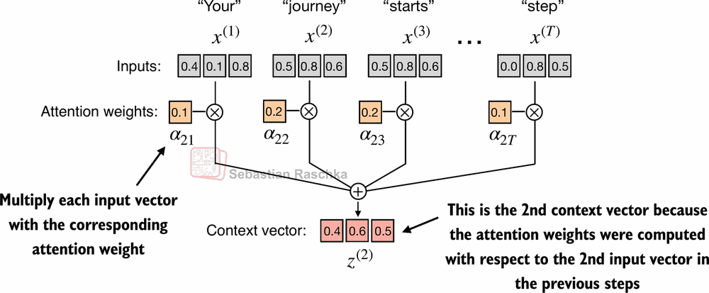

> 🇧🇷 **O que esta célula faz:** Calcula o context vector do segundo token como a soma de todas as entradas ponderadas pelos pesos de atenção. Prints extras mostram o objeto enumerate e, a cada passo, o vetor de entrada e o peso usado.

```python
query = inputs[1] # 2nd input token is the query
print(enumerate(inputs))
context_vec_2 = torch.zeros(query.shape)
for i,x_i in enumerate(inputs):
    print(x_i)
    print(attn_weights_2[i])
    context_vec_2 += attn_weights_2[i]*x_i

print(context_vec_2)
```

```
<enumerate object at 0x7f5634ea7c80>
tensor([0.4300, 0.1500, 0.8900])
tensor(0.1385)
tensor([0.5500, 0.8700, 0.6600])
tensor(0.2379)
tensor([0.5700, 0.8500, 0.6400])
tensor(0.2333)
tensor([0.2200, 0.5800, 0.3300])
tensor(0.1240)
tensor([0.7700, 0.2500, 0.1000])
tensor(0.1082)
tensor([0.0500, 0.8000, 0.5500])
tensor(0.1581)
tensor([0.4419, 0.6515, 0.5683])
```

### 3.3.2 Calculando os pesos de atenção para todos os tokens de entrada

#### Generalizando para todos os tokens da sequência de entrada:

- Acima, calculamos os pesos de atenção e o context vector para a entrada 2 (como ilustrado na linha destacada da figura abaixo)
- A seguir, vamos generalizar esse cálculo para obter todos os pesos de atenção e todos os context vectors

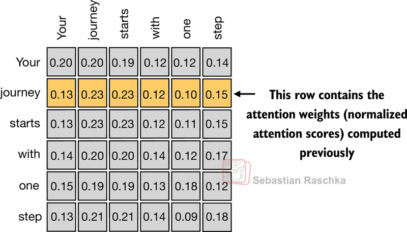

- Na self-attention, o processo começa com o cálculo das pontuações de atenção, que depois são normalizadas para gerar pesos de atenção que somam 1
- Esses pesos de atenção são então usados para gerar os context vectors por meio de uma soma ponderada das entradas

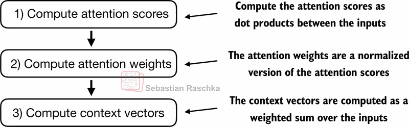

- Aplique o **passo 1** anterior a todos os pares de elementos para calcular a matriz de pontuações de atenção não normalizadas:

> 🇧🇷 **O que esta célula faz:** Calcula, com laços, as pontuações de atenção entre todos os pares de tokens, formando uma matriz 6x6.

```python
attn_scores = torch.empty(6, 6)

for i, x_i in enumerate(inputs):
    for j, x_j in enumerate(inputs):
        attn_scores[i, j] = torch.dot(x_i, x_j)

print(attn_scores)
```

```
tensor([[0.9995, 0.9544, 0.9422, 0.4753, 0.4576, 0.6310],
        [0.9544, 1.4950, 1.4754, 0.8434, 0.7070, 1.0865],
        [0.9422, 1.4754, 1.4570, 0.8296, 0.7154, 1.0605],
        [0.4753, 0.8434, 0.8296, 0.4937, 0.3474, 0.6565],
        [0.4576, 0.7070, 0.7154, 0.3474, 0.6654, 0.2935],
        [0.6310, 1.0865, 1.0605, 0.6565, 0.2935, 0.9450]])
```

- Podemos obter o mesmo resultado de forma mais eficiente por meio de multiplicação de matrizes:

> 🇧🇷 **O que esta célula faz:** Obtém a mesma matriz de pontuações de forma muito mais eficiente, com uma única multiplicação de matrizes.

```python
attn_scores = inputs @ inputs.T
print(attn_scores)
```

```
tensor([[0.9995, 0.9544, 0.9422, 0.4753, 0.4576, 0.6310],
        [0.9544, 1.4950, 1.4754, 0.8434, 0.7070, 1.0865],
        [0.9422, 1.4754, 1.4570, 0.8296, 0.7154, 1.0605],
        [0.4753, 0.8434, 0.8296, 0.4937, 0.3474, 0.6565],
        [0.4576, 0.7070, 0.7154, 0.3474, 0.6654, 0.2935],
        [0.6310, 1.0865, 1.0605, 0.6565, 0.2935, 0.9450]])
```

- De forma semelhante ao **passo 2** anterior, normalizamos cada linha para que os valores de cada linha somem 1:

> 🇧🇷 **O que esta célula faz:** Aplica a softmax em cada linha da matriz, transformando as pontuações em pesos de atenção.

```python
attn_weights = torch.softmax(attn_scores, dim=-1)
print(attn_weights)
```

```
tensor([[0.2098, 0.2006, 0.1981, 0.1242, 0.1220, 0.1452],
        [0.1385, 0.2379, 0.2333, 0.1240, 0.1082, 0.1581],
        [0.1390, 0.2369, 0.2326, 0.1242, 0.1108, 0.1565],
        [0.1435, 0.2074, 0.2046, 0.1462, 0.1263, 0.1720],
        [0.1526, 0.1958, 0.1975, 0.1367, 0.1879, 0.1295],
        [0.1385, 0.2184, 0.2128, 0.1420, 0.0988, 0.1896]])
```

- Uma verificação rápida de que os valores de cada linha realmente somam 1:

> 🇧🇷 **O que esta célula faz:** Confere que cada linha da matriz de pesos de atenção soma 1.

```python
row_2_sum = sum([0.1385, 0.2379, 0.2333, 0.1240, 0.1082, 0.1581])
print("Row 2 sum:", row_2_sum)

print("All row sums:", attn_weights.sum(dim=-1))
```

```
Row 2 sum: 1.0
All row sums: tensor([1.0000, 1.0000, 1.0000, 1.0000, 1.0000, 1.0000])
```

- Aplique o **passo 3** anterior para calcular todos os context vectors:

> 🇧🇷 **O que esta célula faz:** Calcula de uma só vez os context vectors de todos os tokens, multiplicando a matriz de pesos pelas entradas.

```python
all_context_vecs = attn_weights @ inputs
print(all_context_vecs)
```

```
tensor([[0.4421, 0.5931, 0.5790],
        [0.4419, 0.6515, 0.5683],
        [0.4431, 0.6496, 0.5671],
        [0.4304, 0.6298, 0.5510],
        [0.4671, 0.5910, 0.5266],
        [0.4177, 0.6503, 0.5645]])
```

- Como verificação, o context vector calculado anteriormente, $z^{(2)} = [0.4419, 0.6515, 0.5683]$, aparece na 2ª linha do resultado acima:

> 🇧🇷 **O que esta célula faz:** Mostra o context vector calculado antes para o segundo token, que coincide com a segunda linha do resultado anterior.

```python
print("Previous 2nd context vector:", context_vec_2)
```

```
Previous 2nd context vector: tensor([0.4419, 0.6515, 0.5683])
```

## 3.4 Implementando self-attention com pesos treináveis

- Um esquema conceitual que ilustra como o mecanismo de self-attention desenvolvido nesta seção se integra à narrativa e à estrutura geral deste livro e deste capítulo

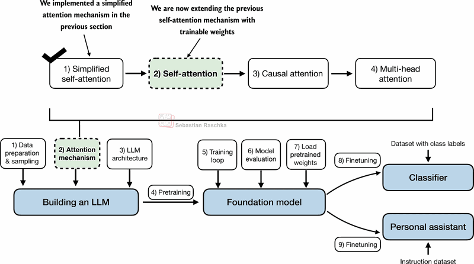